# TiDEomics Application: Macrophage response to six immune stimuli

```
#> The following groups are missing in the custom palette: PC1_top+, PC1_top-, PC2_top+, PC2_top-, PC3_top+
```

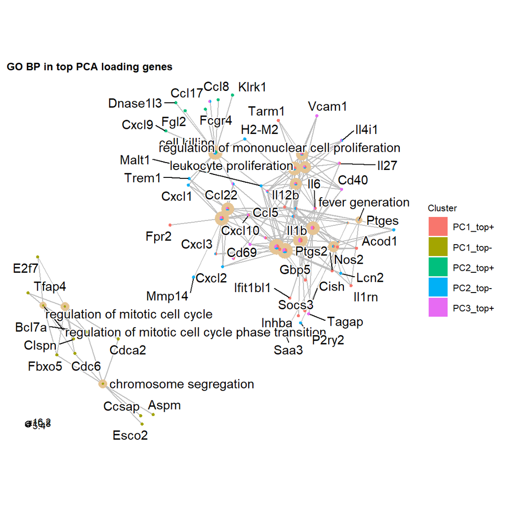

```
#> The following groups are missing in the custom palette: PC1_top+, PC2_top-, PC3_top+
```

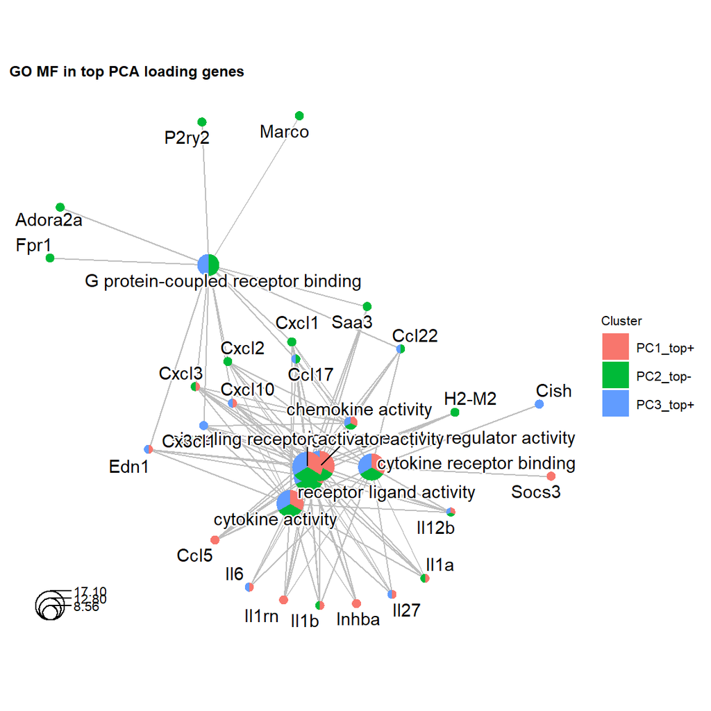

```
#> No significant GO CC terms found.
```

```r
plot_GO(go_list_pca$all,
    plot_cnetplot = TRUE,
    showCategory_cnetplot = 5,
    label = "top PCA loading genes"
)
```

```
#> ℹ Adding new coordinate system, which will replace the existing one.
#> The following groups are missing in the custom palette: PC1_top+, PC1_top-, PC2_top+, PC2_top-, PC3_top+
```

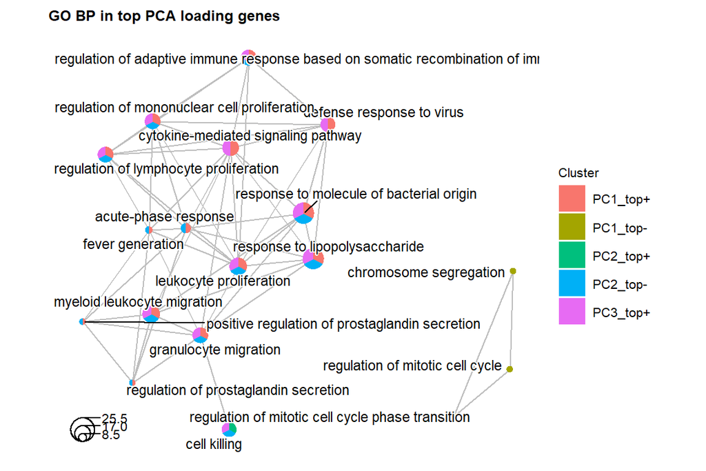

```
#> ℹ Adding new coordinate system, which will replace the existing one.
#> The following groups are missing in the custom palette: PC1_top+, PC2_top-, PC3_top+
```

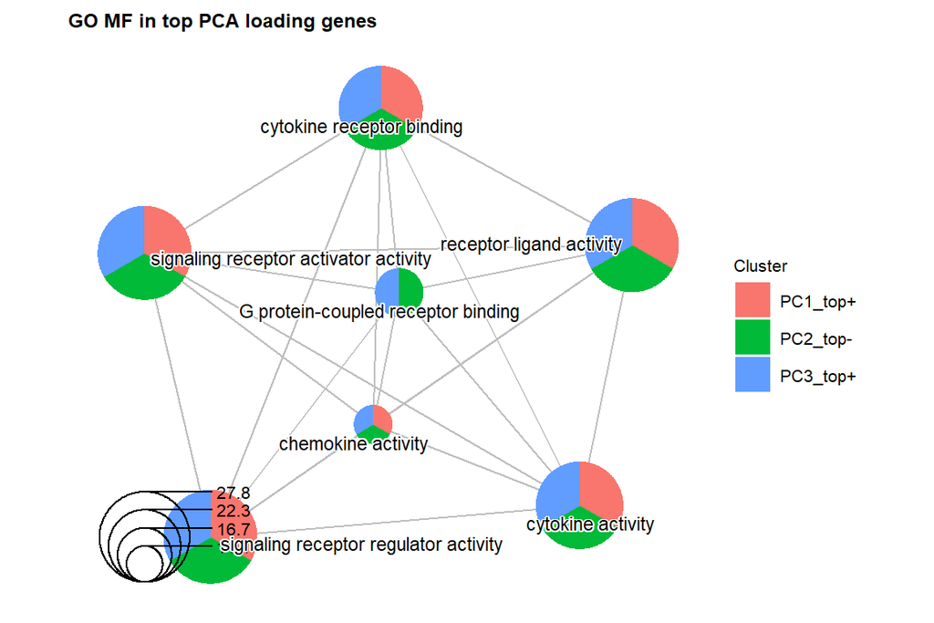

```
#> No significant GO CC terms found.
```

```r
plot_GO(go_list_pca$all,
    plot_emapplot = TRUE,
    showCategory_emapplot = 5,
    label = "top PCA loading genes")
```

## 7.2 Replicates merged by mean

```
#> Group not specified. Plotting all groups: Candida, IFNbeta, IFNgamma, LCMV, Listeria, LPS, untreated
#> Warning: Removed 90 rows containing missing values or values outside the scale range
#> (`geom_point()`).
```

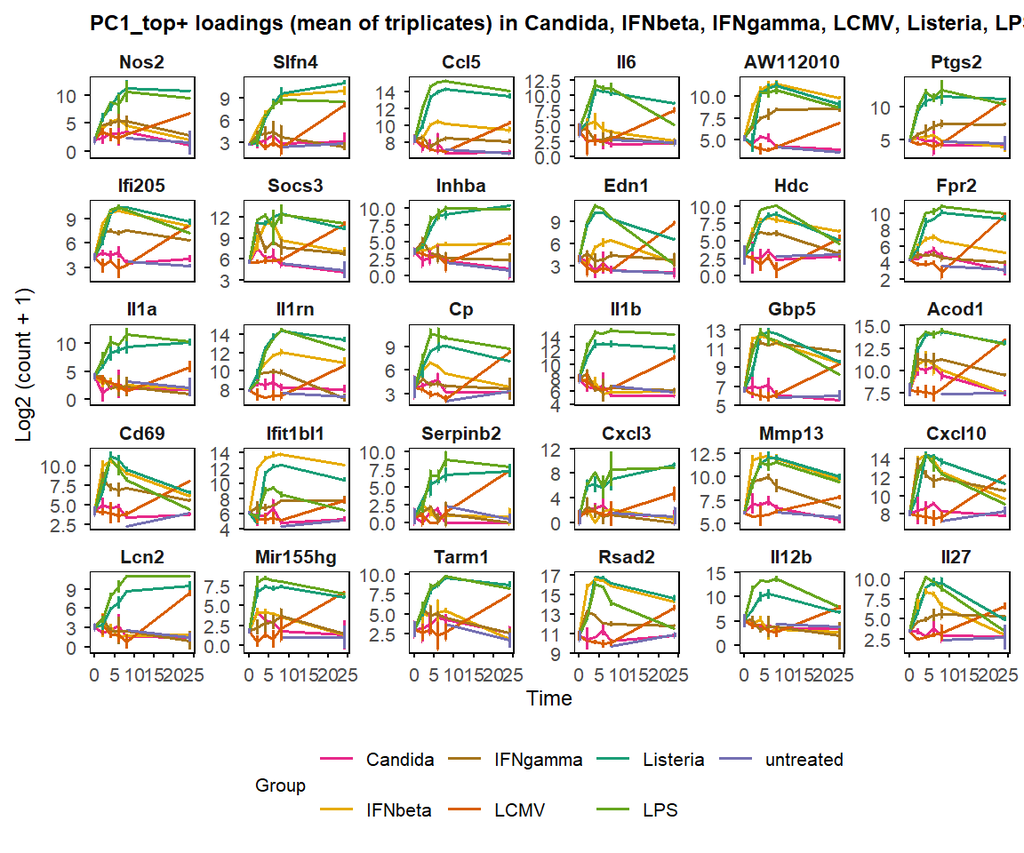

```
#> Group not specified. Plotting all groups: Candida, IFNbeta, IFNgamma, LCMV, Listeria, LPS, untreated
#> Warning: Removed 90 rows containing missing values or values outside the scale range
#> (`geom_point()`).
```

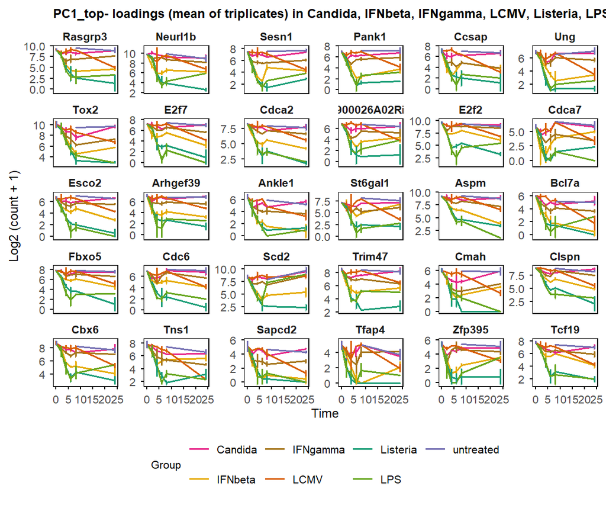

```
#> Group not specified. Plotting all groups: Candida, IFNbeta, IFNgamma, LCMV, Listeria, LPS, untreated
#> Warning: Removed 90 rows containing missing values or values outside the scale range
#> (`geom_point()`).
```

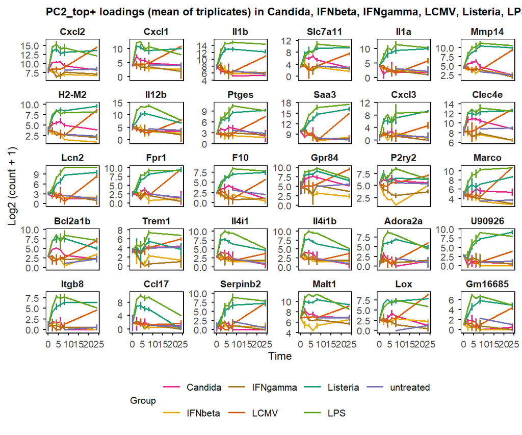

```
#> Group not specified. Plotting all groups: Candida, IFNbeta, IFNgamma, LCMV, Listeria, LPS, untreated
#> Warning: Removed 90 rows containing missing values or values outside the scale range
#> (`geom_point()`).
```

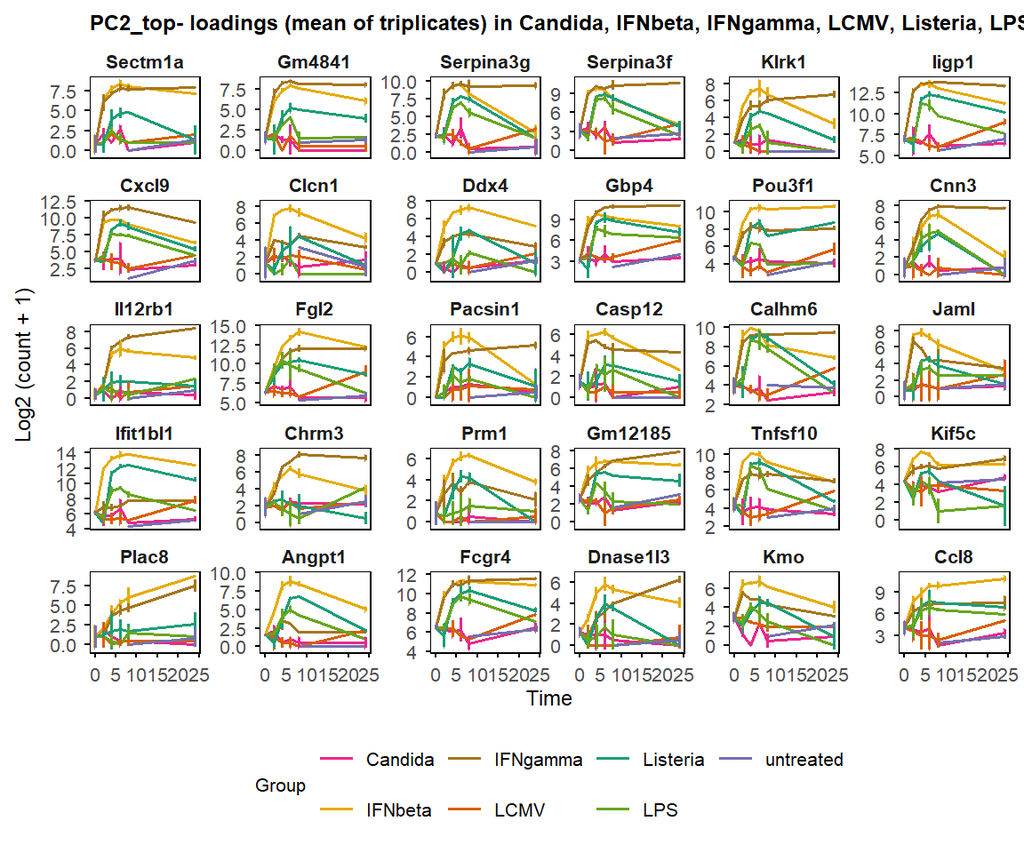

```
#> Group not specified. Plotting all groups: Candida, IFNbeta, IFNgamma, LCMV, Listeria, LPS, untreated
#> Warning: Removed 90 rows containing missing values or values outside the scale range
#> (`geom_point()`).
```

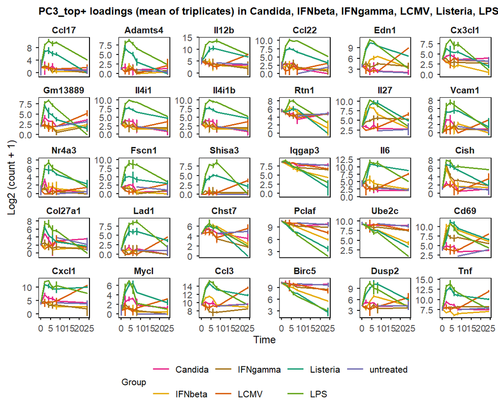

```
#> Group not specified. Plotting all groups: Candida, IFNbeta, IFNgamma, LCMV, Listeria, LPS, untreated
#> Warning: Removed 90 rows containing missing values or values outside the scale range
#> (`geom_point()`).
```

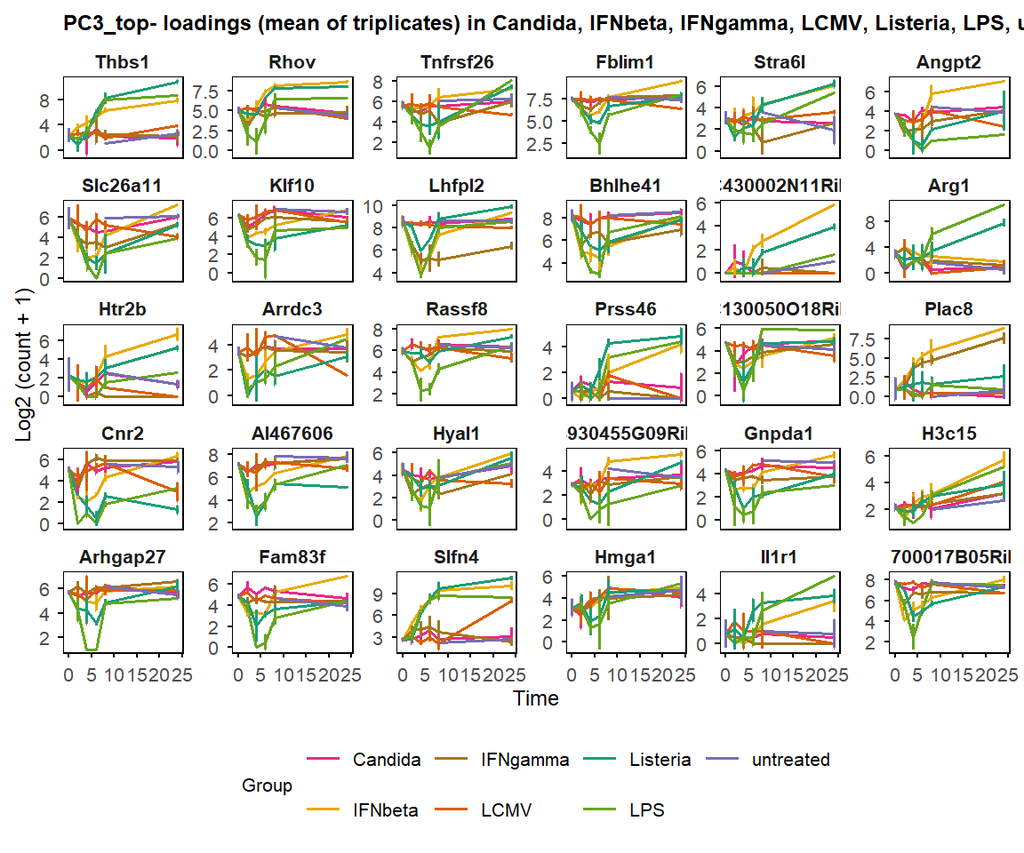

```r
pca_loadings_merged <- PC_merged$loadings %>% as.data.frame()
loadings_list_merged <- list()
top_n <- 30

for (i in 1:3) {
    loadings_list_merged[[paste0("PC", i, "_top+")]] <- pca_loadings_merged %>%
        arrange(desc(get(paste0("PC", i)))) %>%
        head(top_n) %>%
        row.names()
    loadings_list_merged[[paste0("PC", i, "_top-")]] <- pca_loadings_merged %>%
        arrange(get(paste0("PC", i))) %>%
        head(top_n) %>%
        row.names()
}

for (i in names(loadings_list_merged)) {
    plot_trend(table_mean_sd_orig,
        features = loadings_list_merged[[i]],
        title = paste0(i, " loadings (mean of triplicates)"),
        ylab = "Log2 (count + 1)"
    )
}
```

### 7.2.1 GO enrichment

```r
background_pca_merged <- row.names(pca_loadings_merged)

go_list_pca_merged <- enrichGO_list(
    gene_list = loadings_list_merged,
    OrgDb = org.Mm.eg.db,
    universe = background_pca_merged,
    keyType = "SYMBOL",
    simplify = FALSE
)
```

```
#> GO category not specified. Using all three: BP, MF, CC.
#> Performing GO enrichment for category: BP
#> Processing gene list: PC1_top+
#> Processing gene list: PC1_top-
#> Processing gene list: PC2_top+
#> Processing gene list: PC2_top-
#> Processing gene list: PC3_top+
#> Processing gene list: PC3_top-
#> Performing GO enrichment for category: MF
#> Processing gene list: PC1_top+
#> Processing gene list: PC1_top-
#> Processing gene list: PC2_top+
#> Processing gene list: PC2_top-
#> Processing gene list: PC3_top+
#> Processing gene list: PC3_top-
#> Performing GO enrichment for category: CC
#> Processing gene list: PC1_top+
#> Processing gene list: PC1_top-
#> Processing gene list: PC2_top+
#> Processing gene list: PC2_top-
#> Processing gene list: PC3_top+
#> Processing gene list: PC3_top-
#> Merging GO enrichment results across gene lists for each category.
```

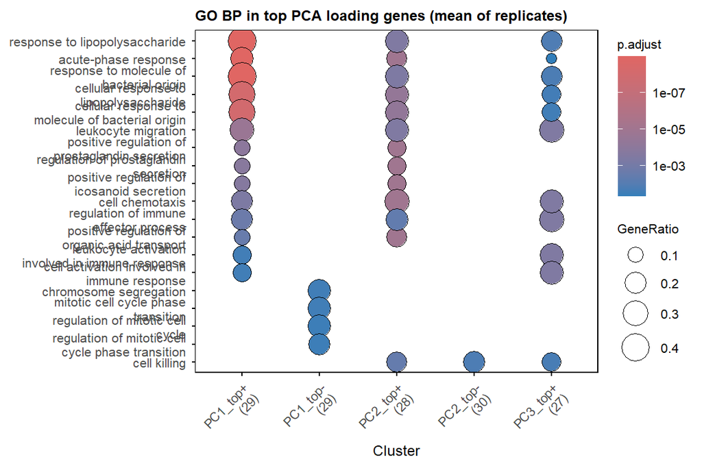

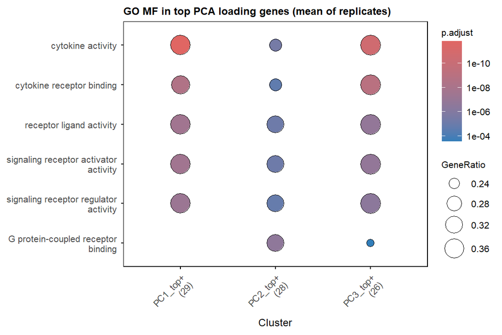

```
#> No significant GO CC terms found.
```

```r
plot_GO(go_list_pca_merged$all,
    plot_dotplot = TRUE,
    showCategory_dotplot = 5,
    label = "top PCA loading genes (mean of replicates)"
)
```

```
#> The following groups are missing in the custom palette: PC1_top+, PC1_top-, PC2_top+, PC2_top-, PC3_top+
```

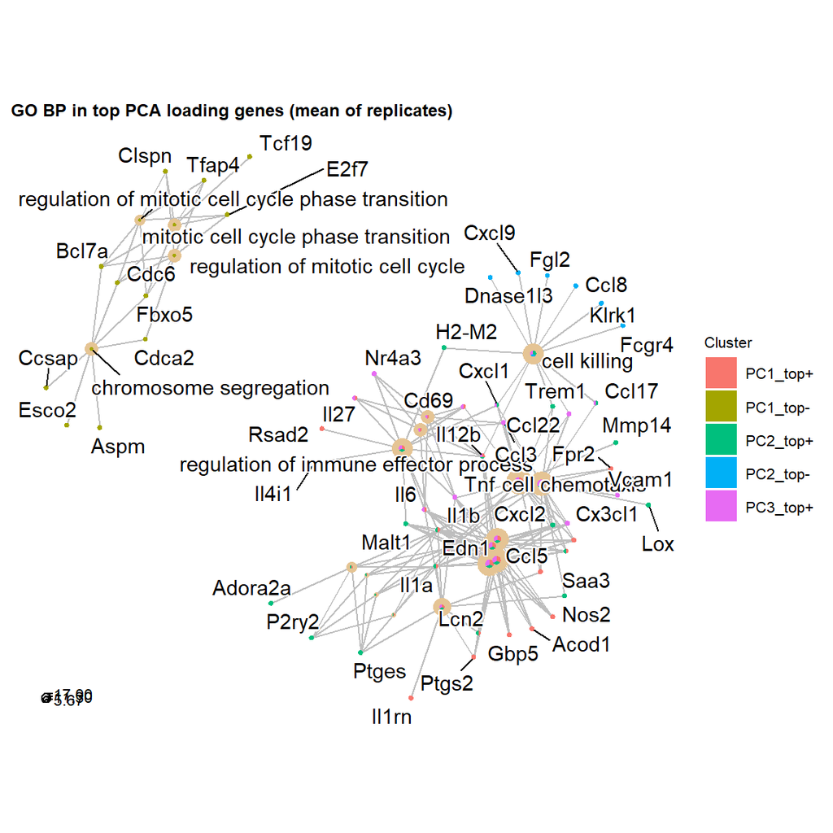

```
#> The following groups are missing in the custom palette: PC1_top+, PC2_top+, PC3_top+
```

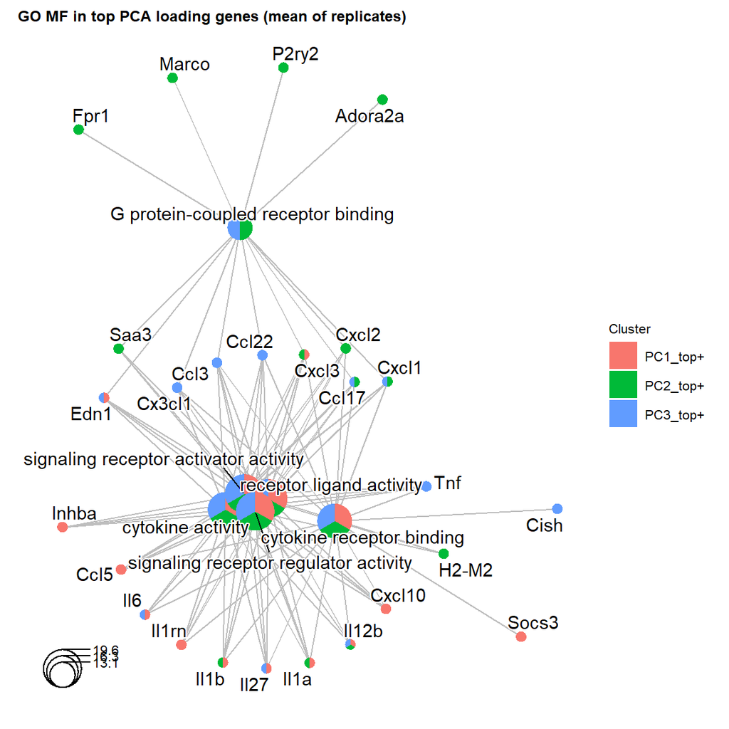

```
#> No significant GO CC terms found.
```

```r
plot_GO(go_list_pca_merged$all,
    plot_cnetplot = TRUE,
    showCategory_cnetplot = 5,
    label = "top PCA loading genes (mean of replicates)"
)
```

```
#> ℹ Adding new coordinate system, which will replace the existing one.
#> The following groups are missing in the custom palette: PC1_top+, PC1_top-, PC2_top+, PC2_top-, PC3_top+
```

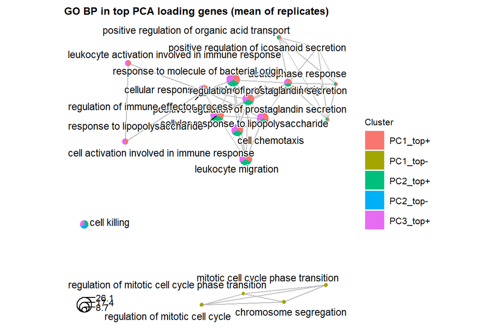

```
#> ℹ Adding new coordinate system, which will replace the existing one.
#> The following groups are missing in the custom palette: PC1_top+, PC2_top+, PC3_top+
```

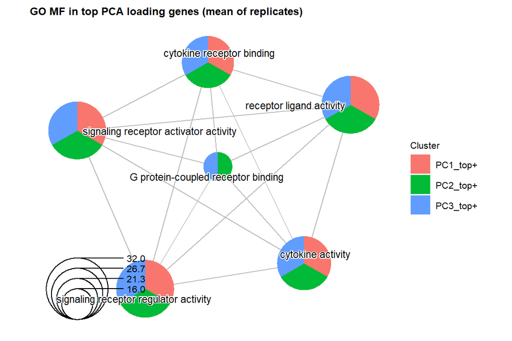

```
#> No significant GO CC terms found.
```

```r
plot_GO(go_list_pca_merged$all,
    plot_emapplot = TRUE,
    showCategory_emapplot = 5,
    label = "top PCA loading genes (mean of replicates)")
```

# 8 Pairwise differential expression (DE)

## 8.1 Between time points within each group

Default DE criteria: p.adj < 0.05, |log2FC| > 1.

`trend = TRUE` is used as recommended for RNA-seq count-derived data to model the mean-variance relationship.

```r
DE_between_time_out <- DE_between_time(data_obj, assay = 1, filter = 1, trend = TRUE)
```

[output not shown]

[output cut: 38 more lines]

```
#> Comparing group LPS time 8 to 0: keeping 20150 of 20150 features (100.0%)
#> Comparing group LPS time 24 to 0: keeping 20150 of 20150 features (100.0%)
#> Comparing group LPS time 4 to 2: keeping 20150 of 20150 features (100.0%)
#> Comparing group LPS time 6 to 2: keeping 20150 of 20150 features (100.0%)
#> Comparing group LPS time 8 to 2: keeping 20150 of 20150 features (100.0%)
#> Comparing group LPS time 24 to 2: keeping 20150 of 20150 features (100.0%)
#> Comparing group LPS time 6 to 4: keeping 20150 of 20150 features (100.0%)
#> Comparing group LPS time 8 to 4: keeping 20150 of 20150 features (100.0%)
#> Comparing group LPS time 24 to 4: keeping 20150 of 20150 features (100.0%)
#> Comparing group LPS time 8 to 6: keeping 20150 of 20150 features (100.0%)
#> Comparing group LPS time 24 to 6: keeping 20150 of 20150 features (100.0%)
#> Comparing group LPS time 24 to 8: keeping 20150 of 20150 features (100.0%)
#> Comparing group untreated time 8 to 0: keeping 20150 of 20150 features (100.0%)
#> Comparing group untreated time 24 to 0: keeping 20150 of 20150 features (100.0%)
#> Comparing group untreated time 24 to 8: keeping 20150 of 20150 features (100.0%)
```

```r
DE_between_time_out$all_list$IFNbeta$`t2-t0` %>% head()
```

|  | Feature | Comparison | Group | Cond1 | Cond2 | RNA_IFNbeta_0h_R1_1 | RNA_IFNbeta_0h_R2_1 | RNA_IFNbeta_2h_R1_1 | RNA_IFNbeta_2h_R2_1 | logFC | P.Value | adj.P.Val |
| --- | --- | --- | --- | --- | --- | --- | --- | --- | --- | --- | --- | --- |
| 1 | 0610005C13Rik | t2-t0 | IFNbeta | 0 | 2 | 0.000000 | 0.000000 | 1.000000 | 0.000000 | 0.5000000 | 3.418150e-01 | 0.680812054 |
| 2 | 0610009E02Rik | t2-t0 | IFNbeta | 0 | 2 | 1.584963 | 1.000000 | 0.000000 | 1.000000 | -0.7924813 | 2.243679e-01 | 0.634795315 |
| 3 | 0610009L18Rik | t2-t0 | IFNbeta | 0 | 2 | 2.321928 | 2.584963 | 2.321928 | 2.321928 | -0.1315172 | 7.341871e-01 | 1.000000000 |
| 4 | 0610030E20Rik | t2-t0 | IFNbeta | 0 | 2 | 7.392317 | 7.734710 | 6.807355 | 6.845490 | -0.7370910 | 2.213968e-02 | 0.198535644 |
| 5 | 0610039K10Rik | t2-t0 | IFNbeta | 0 | 2 | 0.000000 | 0.000000 | 0.000000 | 1.000000 | 0.5000000 | 3.418150e-01 | 0.680812054 |
| 6 | 0610043K17Rik | t2-t0 | IFNbeta | 0 | 2 | 0.000000 | 0.000000 | 1.584963 | 1.584963 | 1.5849625 | 8.658367e-06 | 0.001125588 |

```r
DE_between_time_out$de_list$IFNbeta$`t2-t0` %>% head()
```

|  | Feature | Comparison | Group | Cond1 | Cond2 | logFC | adj.P.Val |
| --- | --- | --- | --- | --- | --- | --- | --- |
| 1 | 0610043K17Rik | t2-t0 | IFNbeta | 0 | 2 | 1.584963 | 0.001125588 |
| 2 | 1110020A21Rik | t2-t0 | IFNbeta | 0 | 2 | -1.584963 | 0.001125588 |
| 3 | 1700017B05Rik | t2-t0 | IFNbeta | 0 | 2 | -3.733803 | 0.017203708 |
| 4 | 9930111J21Rik2 | t2-t0 | IFNbeta | 0 | 2 | 1.353803 | 0.016486912 |
| 5 | Abl2 | t2-t0 | IFNbeta | 0 | 2 | 1.460122 | 0.047525419 |
| 6 | Arhgef3 | t2-t0 | IFNbeta | 0 | 2 | 2.090352 | 0.043877454 |

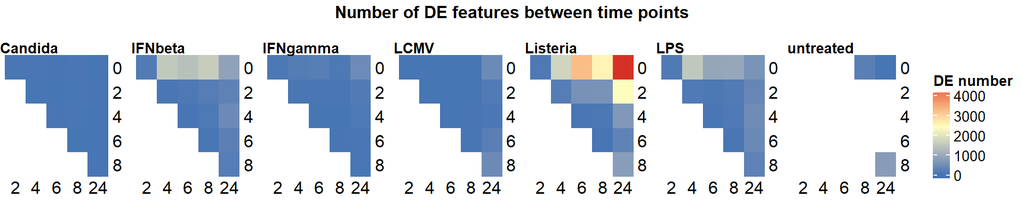

```r
plot_DE_between_time(data_obj,
    de_list = DE_between_time_out$de_list,
    fontsize = 8, value = FALSE, nrow = 1, heatmap_width = 3
)
```

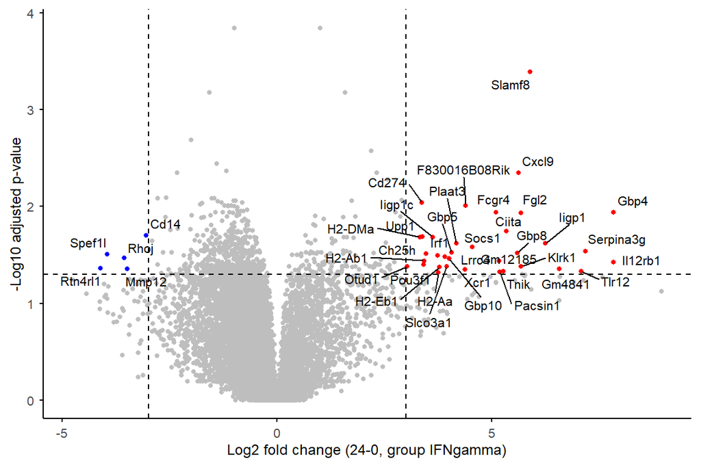

```r
plot_volcano(DE_between_time_out,
    group = "IFNgamma", time1 = 0, time2 = 24,
    logFC_thres = 3, adjP_thres = 0.05, label = TRUE)
```

## 8.2 Between groups at each time point

Default DE criteria: p.adj < 0.05, |log2FC| > 1. `trend = TRUE` for RNA-seq.

All groups use untreated time 0 data, so no DE features at time point 0

```r
DE_between_group_out <- DE_between_group(data_obj, assay = 2,
    group = "untreated", trend = TRUE)
```

[output not shown]

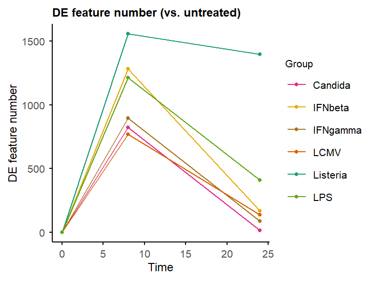

```r
DE_between_group_out$all_list$`IFNgamma-untreated`$`24` %>% head()
```

|  | Feature | Comparison | Time | Cond1 | Cond2 | RNA_untreated_24h_R1_2 | RNA_untreated_24h_R2_2 | RNA_IFNgamma_24h_R1_2 | RNA_IFNgamma_24h_R2_2 | logFC | P.Value | adj.P.Val |
| --- | --- | --- | --- | --- | --- | --- | --- | --- | --- | --- | --- | --- |
| 1 | 0610005C13Rik | IFNgamma-untreated | 24 | untreated | IFNgamma | 0.0000000 | 1.0000000 | 0.0000000 | 0.0000000 | -0.5000000 | 0.371664456 | 0.7556785 |
| 2 | 0610009E02Rik | IFNgamma-untreated | 24 | untreated | IFNgamma | -1.2924813 | -1.2924813 | 0.2924813 | -0.2924813 | 1.2924813 | 0.027826725 | 0.3160909 |
| 3 | 0610009L18Rik | IFNgamma-untreated | 24 | untreated | IFNgamma | -0.4534453 | 1.0059863 | -1.4534453 | -0.1315172 | -1.0687518 | 0.339374389 | 0.7556785 |
| 4 | 0610030E20Rik | IFNgamma-untreated | 24 | untreated | IFNgamma | -0.1798092 | -0.2147854 | -0.5635135 | -0.5082311 | -0.3385750 | 0.004013588 | 0.1629906 |
| 5 | 0610039K10Rik | IFNgamma-untreated | 24 | untreated | IFNgamma | 0.0000000 | 1.5849625 | 2.0000000 | 1.0000000 | 0.7075187 | 0.482976480 | 0.8908676 |
| 6 | 0610043K17Rik | IFNgamma-untreated | 24 | untreated | IFNgamma | 1.5849625 | 1.0000000 | 1.5849625 | 0.0000000 | -0.5000000 | 0.573900864 | 0.9953757 |

```r
DE_between_group_out$de_list$`IFNgamma-untreated` %>% head()
```

|  | Feature | Comparison | Time | Cond1 | Cond2 | logFC | adj.P.Val |
| --- | --- | --- | --- | --- | --- | --- | --- |
| 1 | 1500002C15Rik | IFNgamma-untreated | 8 | untreated | IFNgamma | 1.584963 | 0.01483807 |
| 2 | 1700003E16Rik | IFNgamma-untreated | 8 | untreated | IFNgamma | -1.000000 | 0.01483807 |
| 3 | 1700011B04Rik | IFNgamma-untreated | 8 | untreated | IFNgamma | 1.584963 | 0.01906712 |
| 4 | 1700016G22Rik | IFNgamma-untreated | 8 | untreated | IFNgamma | -1.000000 | 0.01483807 |
| 5 | 1700028I16Rik | IFNgamma-untreated | 8 | untreated | IFNgamma | -1.584963 | 0.01483807 |
| 6 | 1700055D18Rik | IFNgamma-untreated | 8 | untreated | IFNgamma | -1.584963 | 0.01483807 |

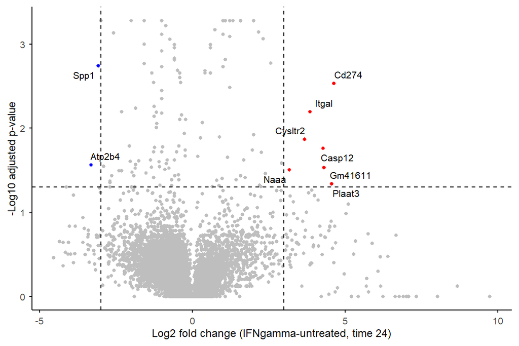

```r
plot_volcano(DE_between_group_out,
    group1 = "untreated", group2 = "IFNgamma", time = 24,
    logFC_thres = 3, adjP_thres = 0.05, label = TRUE)
```

# 9 Differentially expressed genes (DEG) classified by feature properties

## 9.1 Calculate expression ratio, randomness, maximum overall fold change

use data not normalised to time 0, replicates merged by mean.

```r
data_obj_merged_list <- calc_feature_property(data_obj_merged_list, threshold = 0)
property_random_fc <- summarise_feature_property(data_obj_merged_list)

head(property_random_fc)
```

|  | Feature | Group | Exp_threshold | T_exp | T_total | P_trend | Max_FC | Max_FC_time | Exp_ratio |
| --- | --- | --- | --- | --- | --- | --- | --- | --- | --- |
| 1 | 0610005C13Rik | Candida | 0 | 1 | 6 | NA | 1.0000000 | 4 | 0.1666667 |
| 2 | 0610009E02Rik | Candida | 0 | 5 | 6 | 0.8460143 | 1.9534453 | -2 | 0.8333333 |
| 3 | 0610009L18Rik | Candida | 0 | 6 | 6 | 0.8909002 | 1.7297158 | 16 | 1.0000000 |
| 4 | 0610030E20Rik | Candida | 0 | 6 | 6 | 0.5972618 | 0.4997581 | -4 | 1.0000000 |
| 5 | 0610039K10Rik | Candida | 0 | 1 | 6 | NA | 0.5000000 | 2 | 0.1666667 |
| 6 | 0610043K17Rik | Candida | 0 | 2 | 6 | NA | 1.0000000 | 2 | 0.3333333 |

## 9.2 Non-random DEG in each group

DEG: max overall fold change >= fold change threshold (2 fold)

```r
filter_list <- list() # genes with at least certain values > threshold (0)

non_random_list <- list()
non_random_up_list <- list()
non_random_down_list <- list()

filter_ratio <- 0.5 # minimum expressed in 50% samples
max_fc_thres <- 1 # two fold changes in log2 scale

for (i in unique(data_obj$Group)) {
    filter_list[[i]] <- property_random_fc %>%
        filter(Group == i) %>%
        filter(Exp_ratio > filter_ratio) %>%
        pull(Feature)

    non_random_list[[i]] <- property_random_fc %>%
        filter(Group == i) %>%
        filter(P_trend < 0.05 & Exp_ratio > filter_ratio) %>%
        pull(Feature)

    non_random_up_list[[i]] <- property_random_fc %>%
        filter(Group == i) %>%
        filter(P_trend < 0.05 & Exp_ratio > filter_ratio &
            Max_FC >= max_fc_thres & Max_FC_time > 0) %>%
        pull(Feature)
    non_random_down_list[[i]] <- property_random_fc %>%
        filter(Group == i) %>%
        filter(P_trend < 0.05 & Exp_ratio > filter_ratio &
            Max_FC >= max_fc_thres & Max_FC_time < 0) %>%
        pull(Feature)
}
```

```r
non_random_up_list %>% lapply(length)
```

```
#> $Candida
#> [1] 168
#>
#> $IFNbeta
#> [1] 579
#>
#> $IFNgamma
#> [1] 336
#>
#> $LCMV
#> [1] 591
#>
#> $Listeria
#> [1] 372
#>
#> $LPS
#> [1] 279
#>
#> $untreated
#> [1] 0
non_random_down_list %>% lapply(length)
```

```
#> $Candida
#> [1] 146
#>
#> $IFNbeta
#> [1] 2036
#>
#> $IFNgamma
#> [1] 808
#>
#> $LCMV
#> [1] 621
#>
#> $Listeria
#> [1] 3353
#>
#> $LPS
#> [1] 1704
#>
#> $untreated
#> [1] 0
```

The untreated group with only 3 time points doesn’t have non-random DEG.

## 9.3 Visualise example non-random DEGs

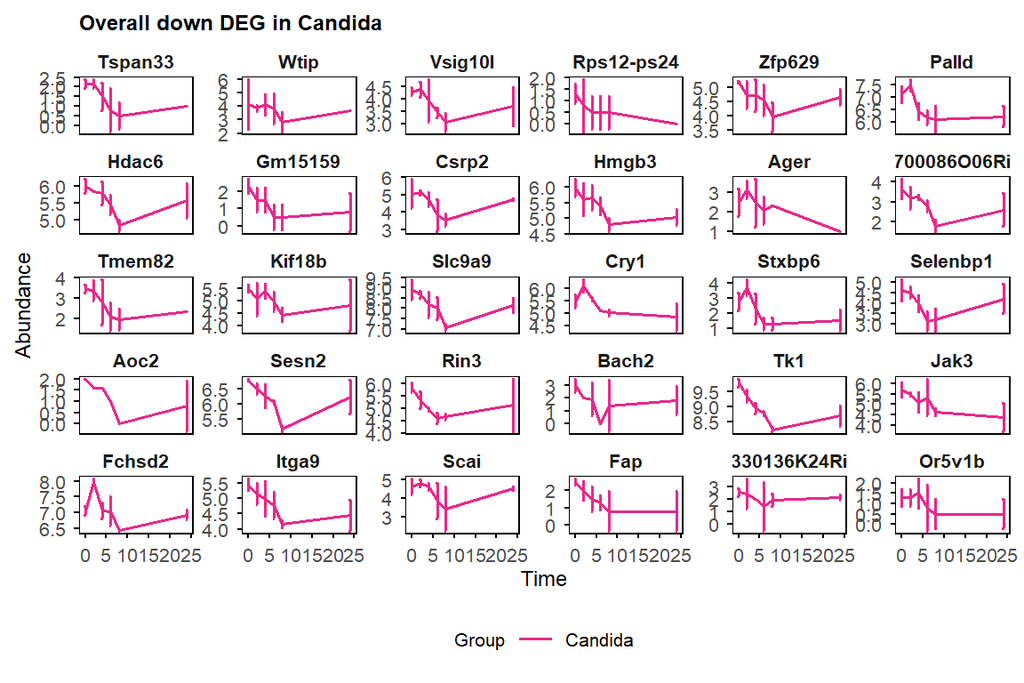

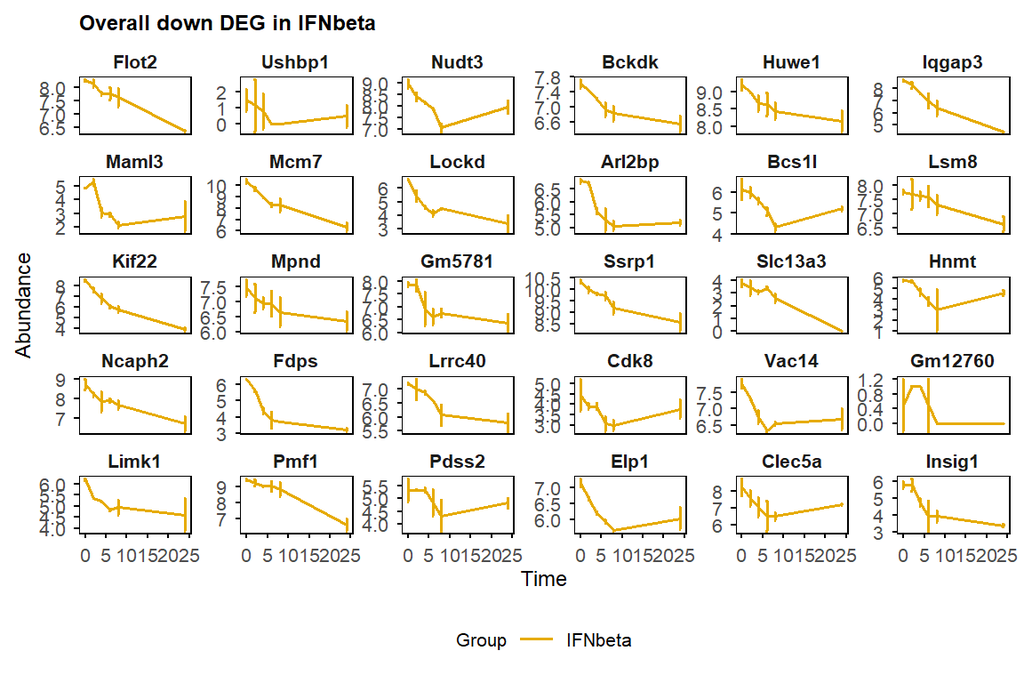

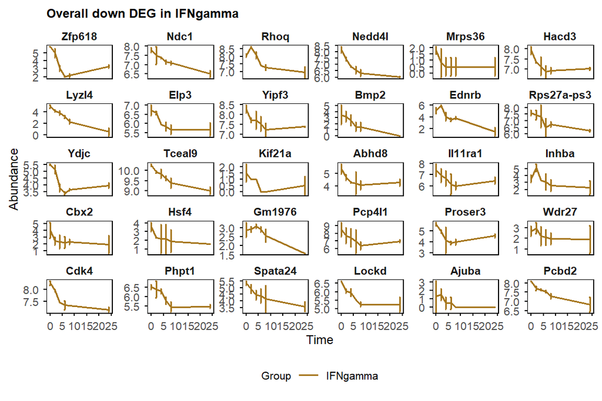

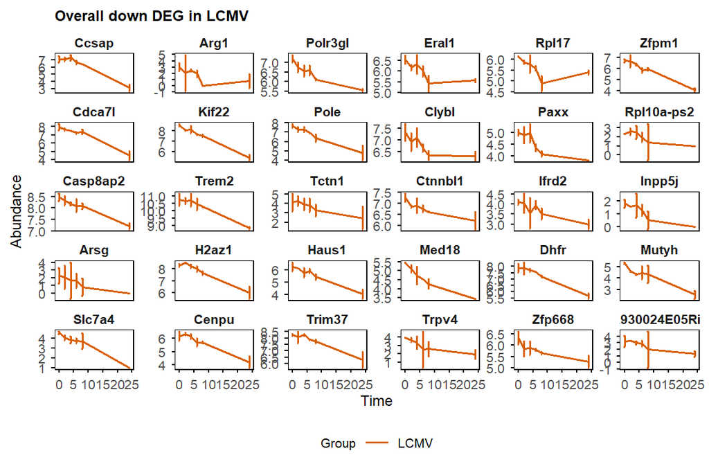

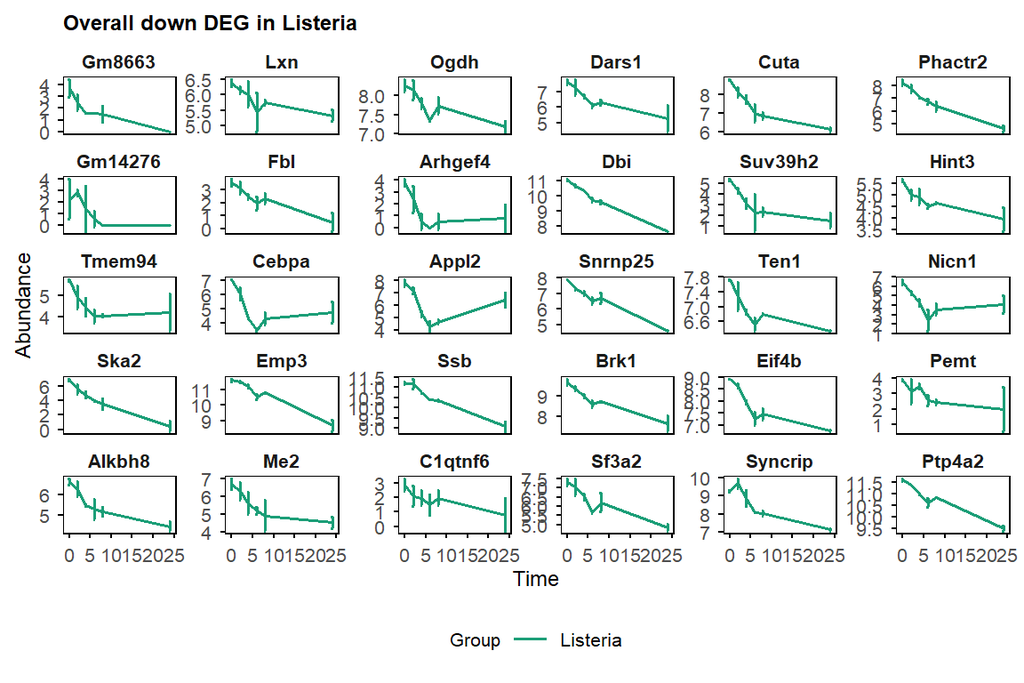

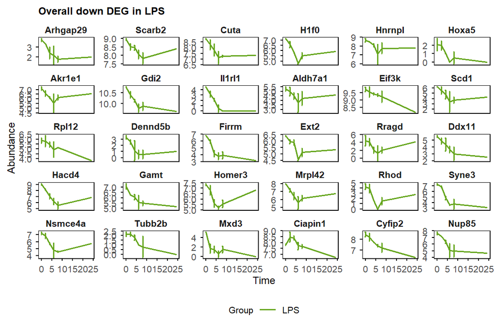

```r
for (i in unique(data_obj$Group)) {
    random <- sample(non_random_down_list[[i]],
                     min(30, length(non_random_down_list[[i]])))

    if (length(random) == 0) {
        next
    }
    # mean, sd
    plot_trend(table_mean_sd_orig,
        groups = i,
        features = random, title = "Overall down DEG"
    )
}
```

## 9.4 GO enrichment of overall DEGs

Simplified enrichment can be customised with parameters: `simplify_cutoff`, `simplify_by`, `simplify_select_fun`, `simplify_measure`.

```r
go_list_up_merged <- enrichGO_list(
    gene_list = non_random_up_list,
    OrgDb = org.Mm.eg.db,
    universe_list = filter_list,
    keyType = "SYMBOL",
    simplify = TRUE
)
```

[output not shown]

```r
go_list_down_merged <- enrichGO_list(
    gene_list = non_random_down_list,
    OrgDb = org.Mm.eg.db,
    universe_list = filter_list,
    keyType = "SYMBOL",
    simplify = TRUE
)
```

[output not shown]

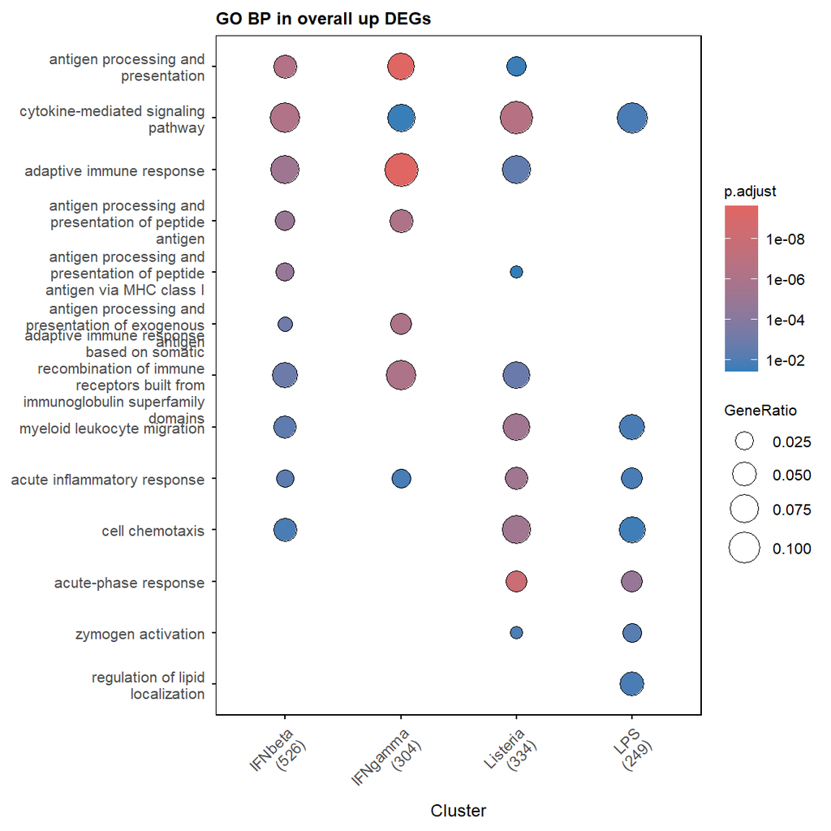

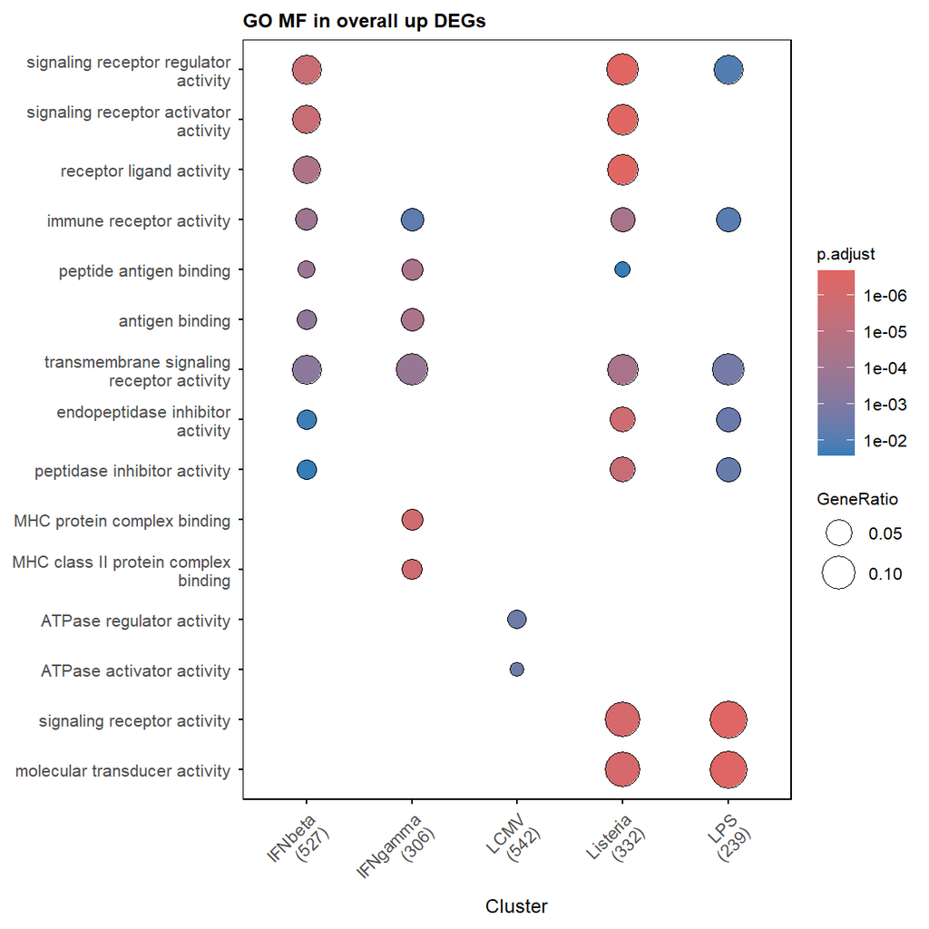

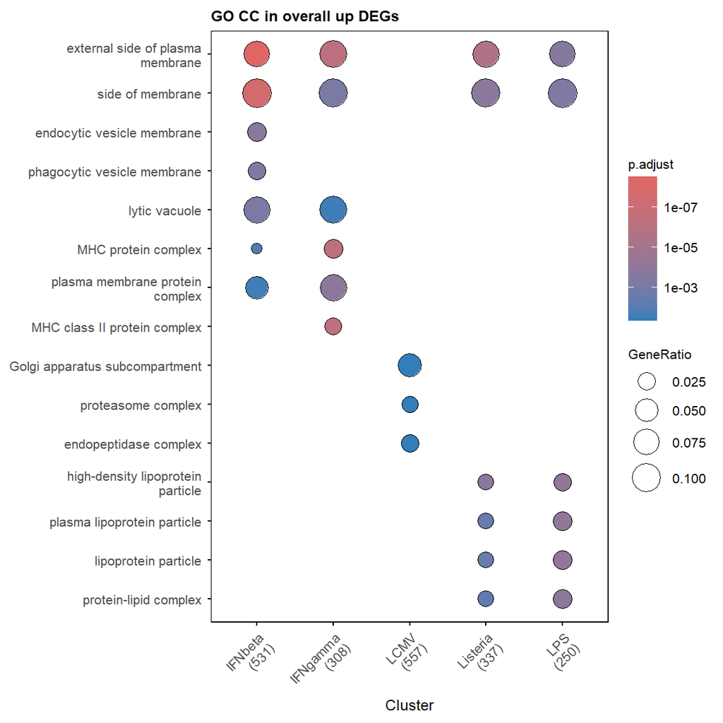

```r
plot_GO(go_list_up_merged$all,
    plot_dotplot = TRUE,
    showCategory_dotplot = 5,
    label = "overall up DEGs"
)
```

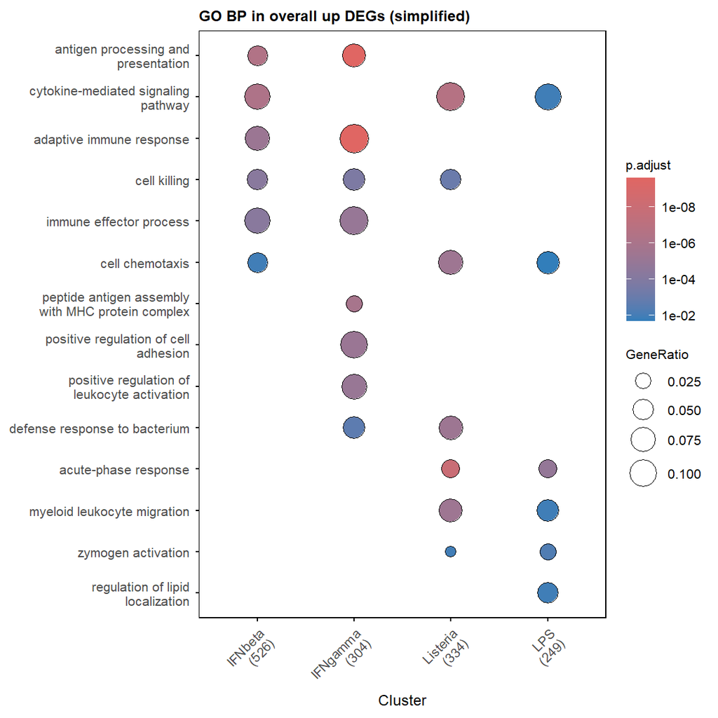

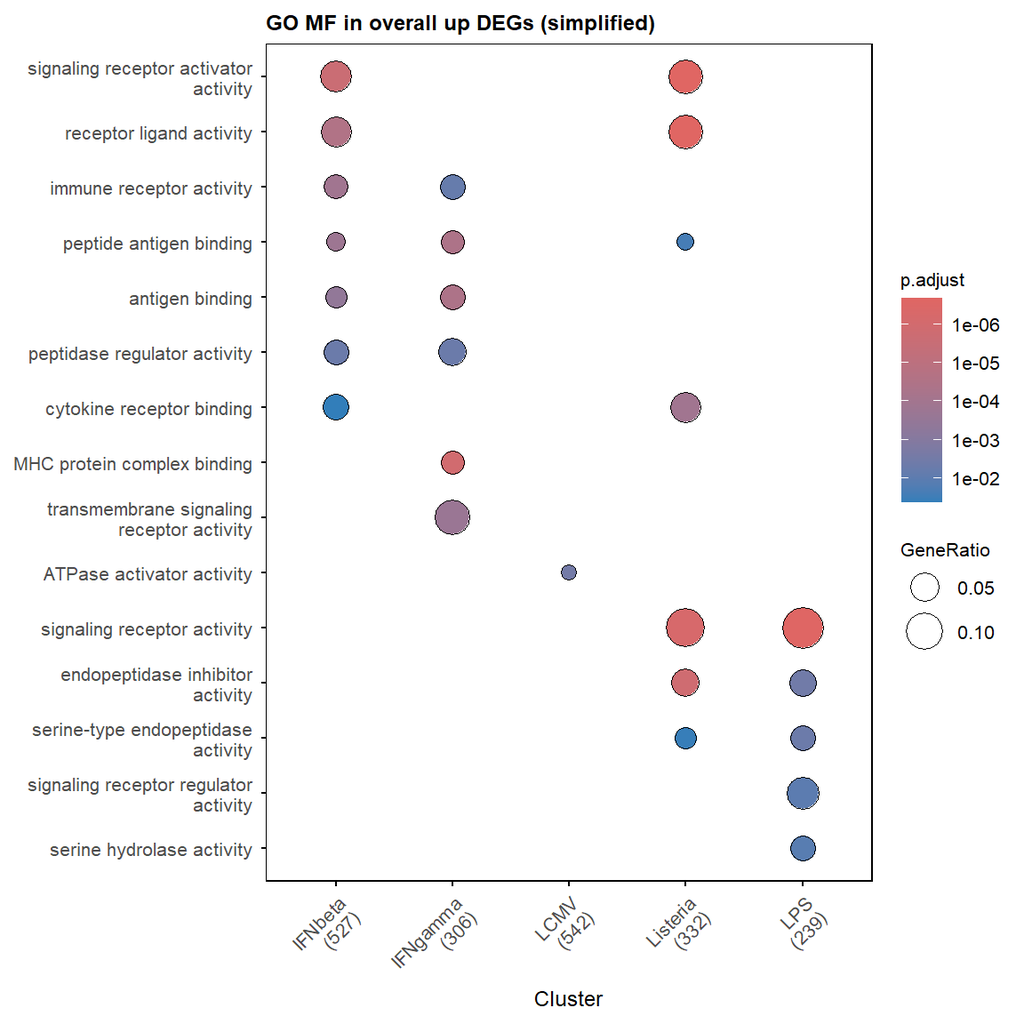

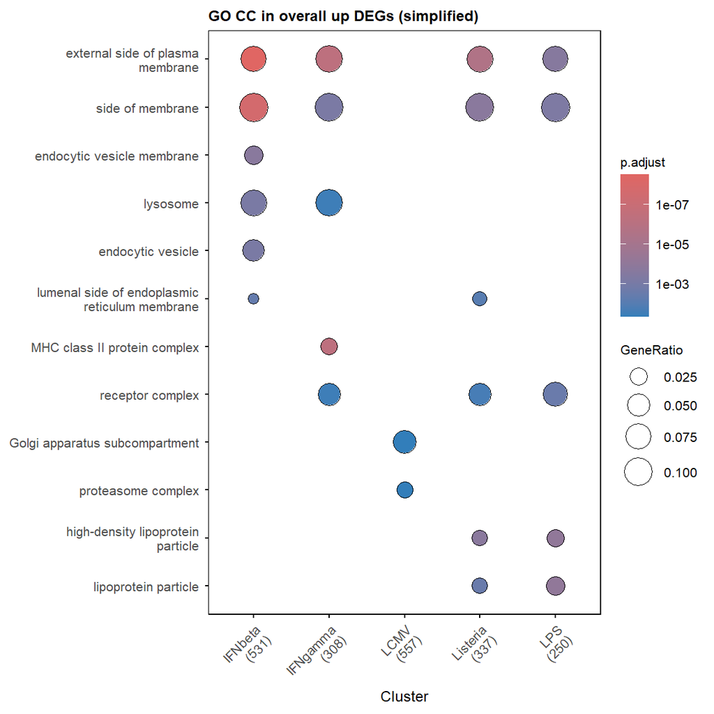

```r
plot_GO(go_list_up_merged$simplified,
    plot_dotplot = TRUE,
    showCategory_dotplot = 5,
    label = "overall up DEGs (simplified)"
)
```

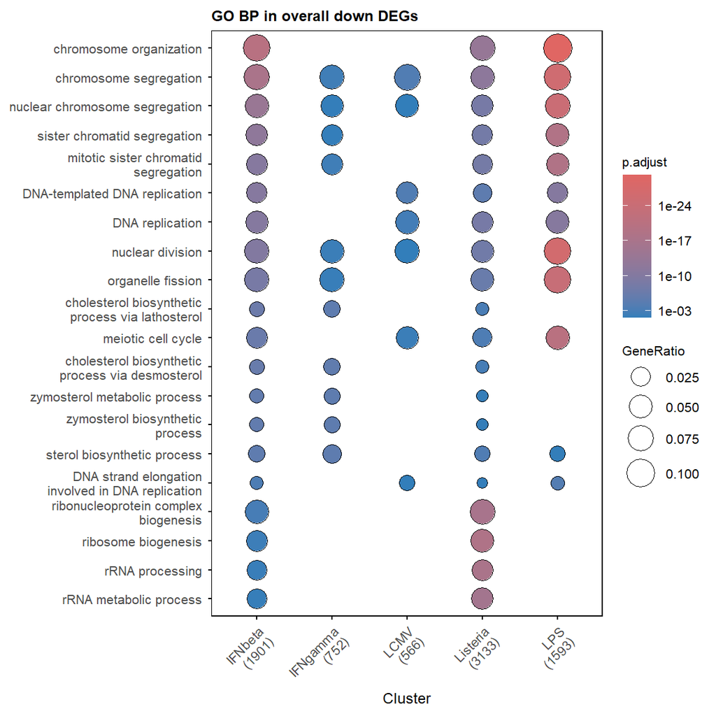

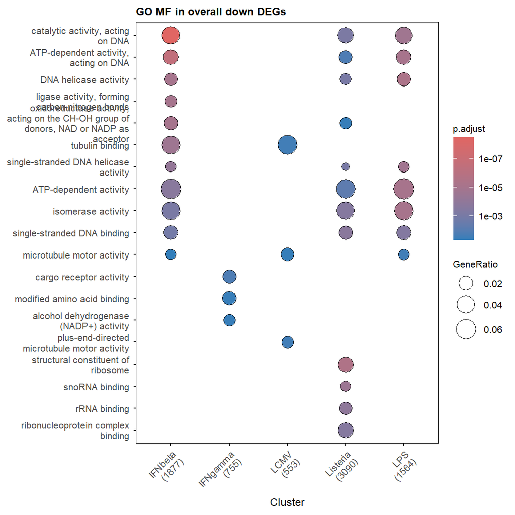

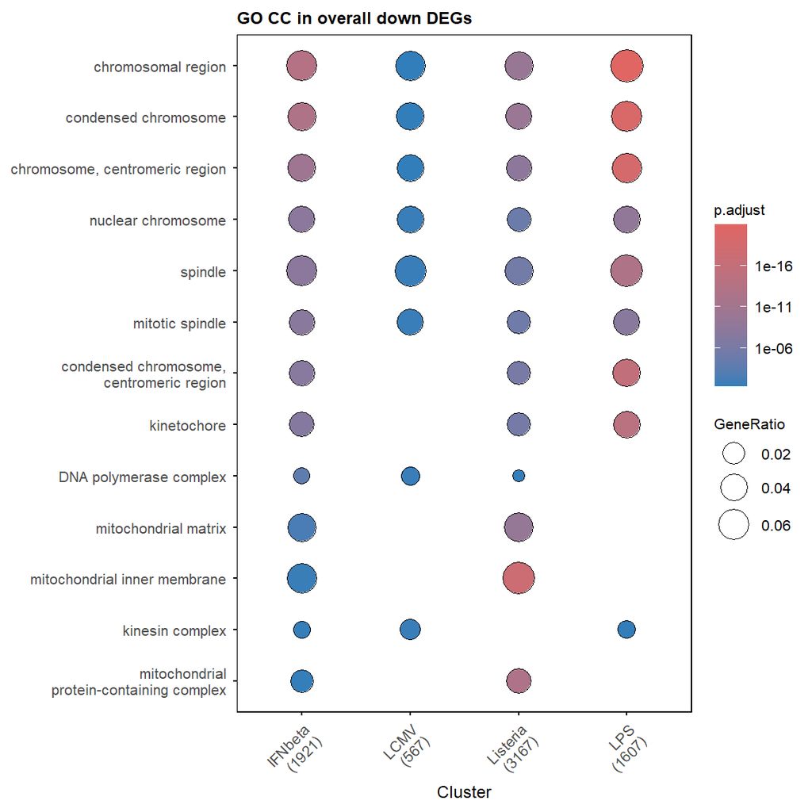

```r
plot_GO(go_list_down_merged$all,
    plot_dotplot = TRUE,
    showCategory_dotplot = 5,
    label = "overall down DEGs"
)
```

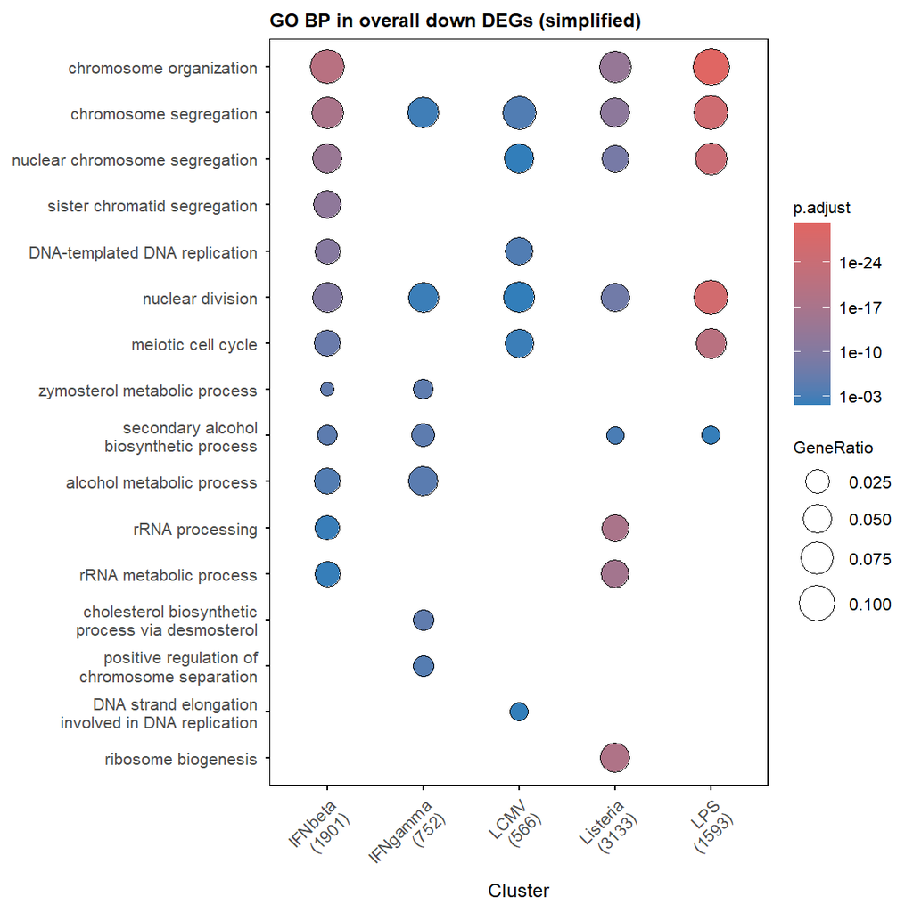

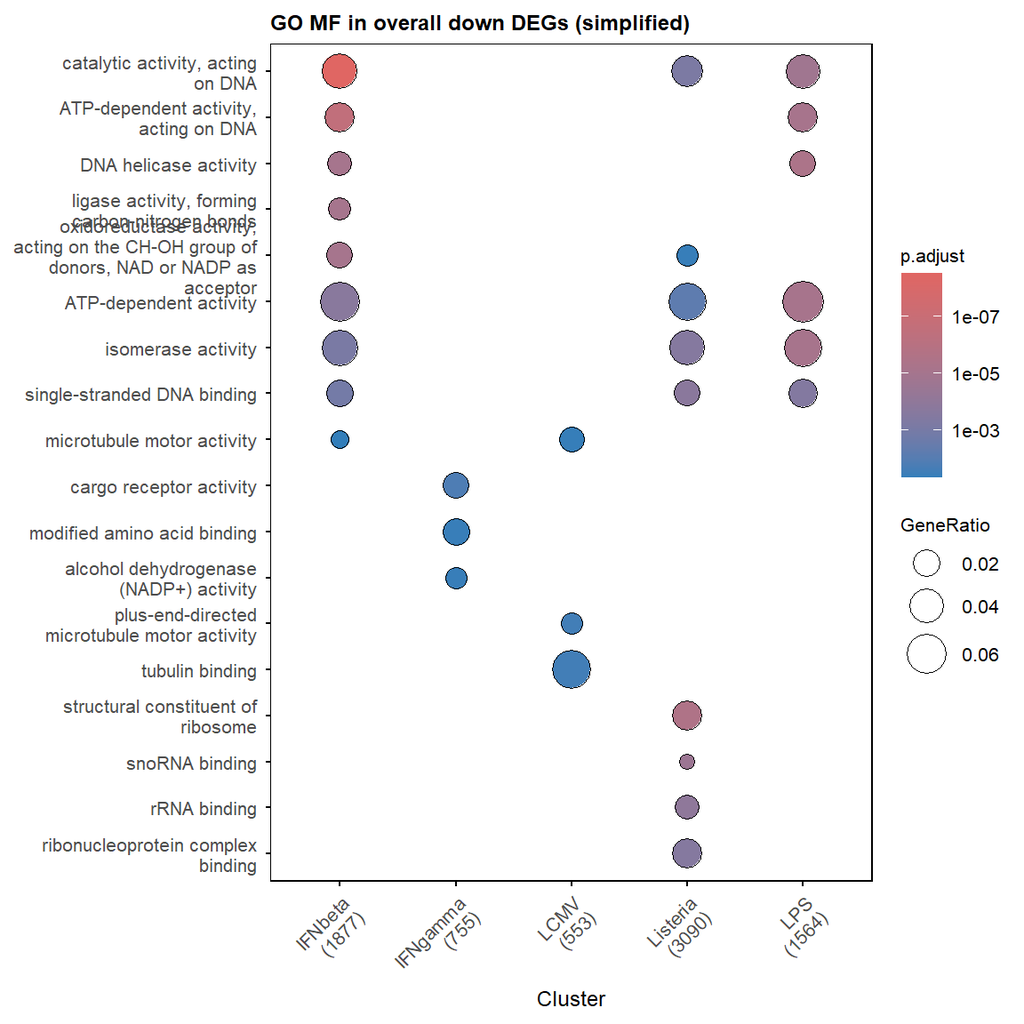

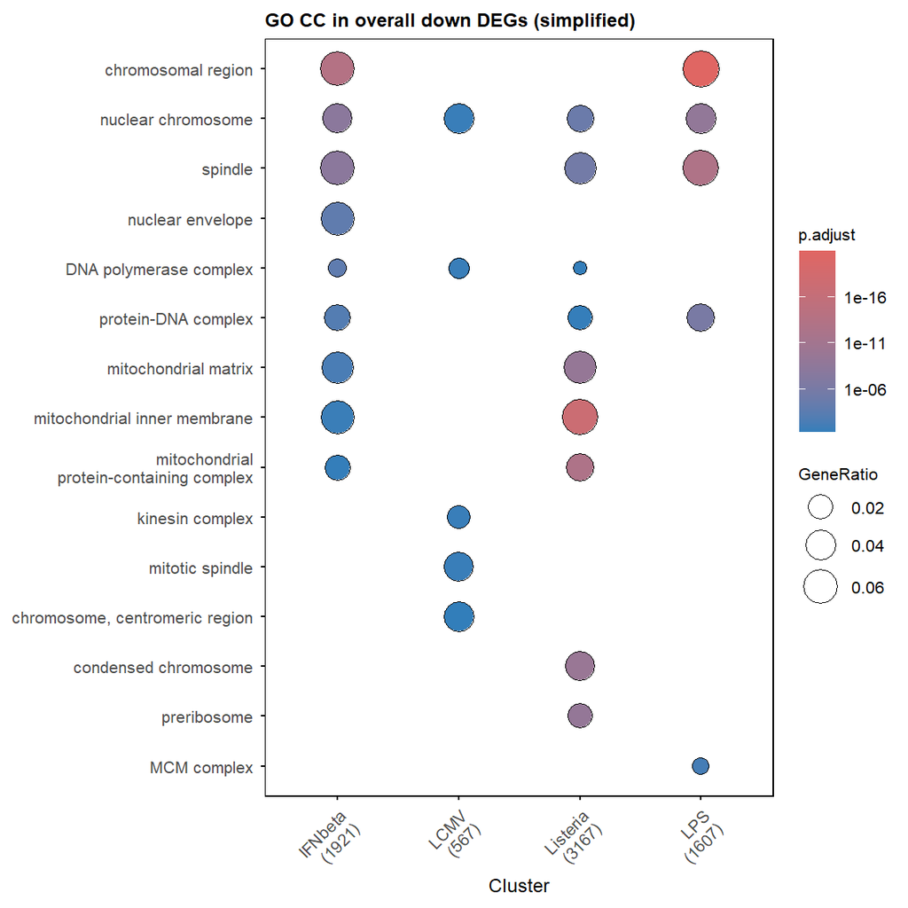

```r
plot_GO(go_list_down_merged$simplified,
    plot_dotplot = TRUE,
    showCategory_dotplot = 5,
    label = "overall down DEGs (simplified)"
)
```

```
#> ℹ Adding new coordinate system, which will replace the existing one.
```

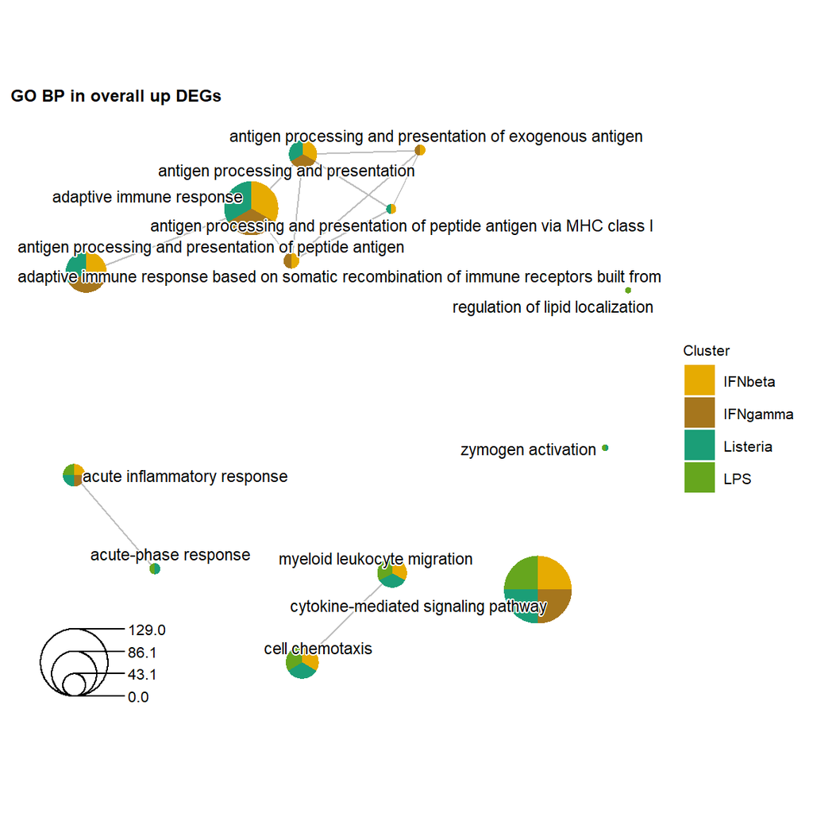

```
#> ℹ Adding new coordinate system, which will replace the existing one.
```

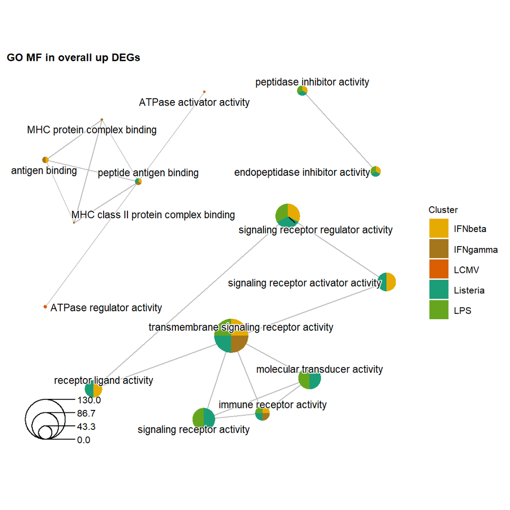

```
#> ℹ Adding new coordinate system, which will replace the existing one.
```

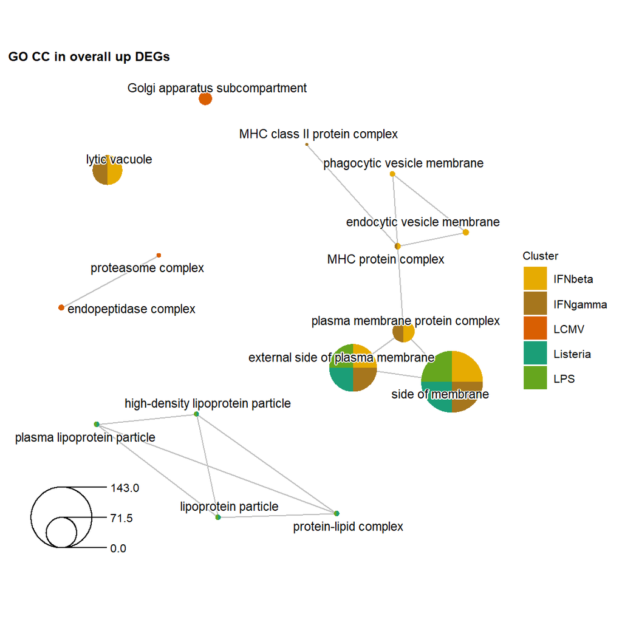

```r
plot_GO(go_list_up_merged$all,
    plot_emapplot = TRUE,
    showCategory_emapplot = 5,
    label = "overall up DEGs"
)
```

```
#> ℹ Adding new coordinate system, which will replace the existing one.
```

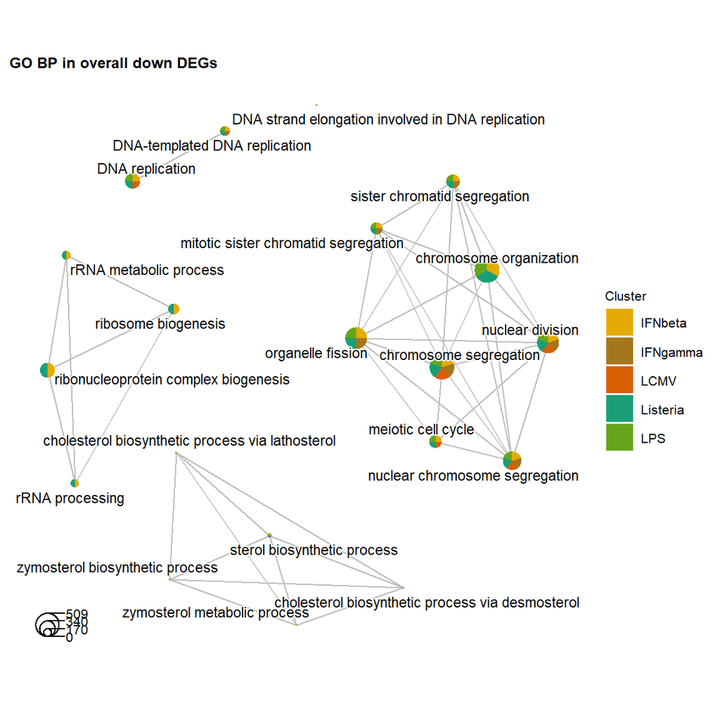

```
#> ℹ Adding new coordinate system, which will replace the existing one.
```

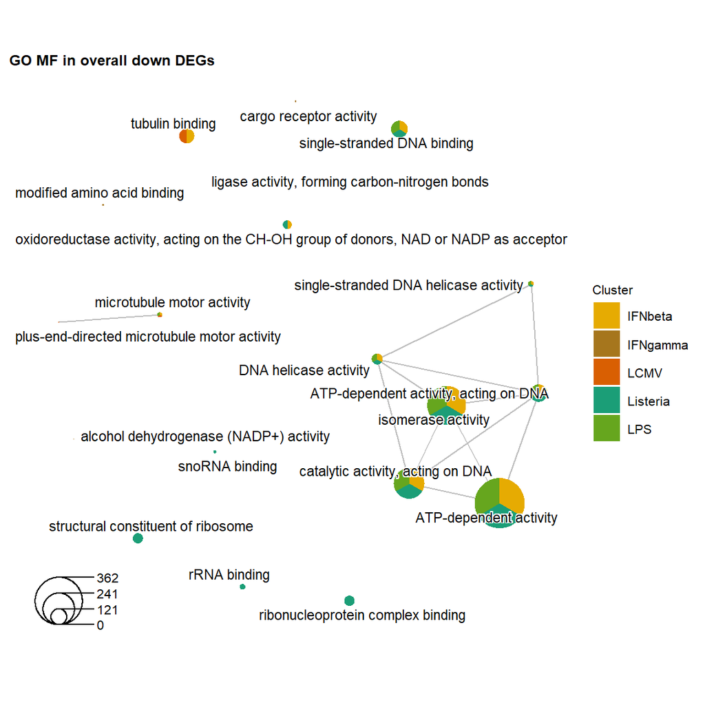

```
#> ℹ Adding new coordinate system, which will replace the existing one.
```

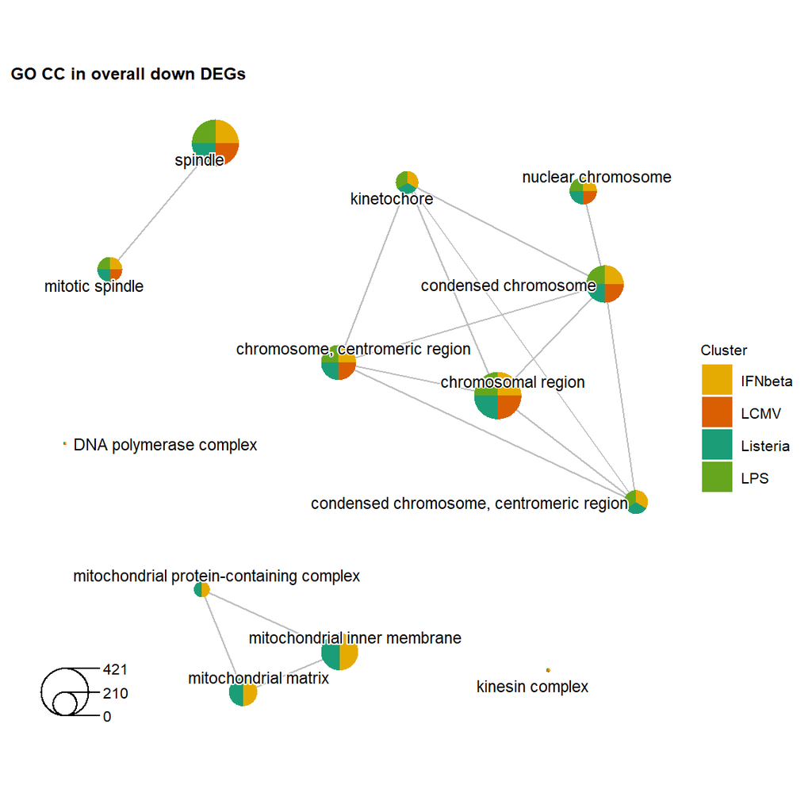

```r
plot_GO(go_list_down_merged$all,
    plot_emapplot = TRUE,
    showCategory_emapplot = 5,
    label = "overall down DEGs"
)
```

## 9.5 Group-specifically expressed genes

genes expressed in only one group with >50% values >0.

```r
filter_ratio <- 0.5

group_unique_genes_list <- list()
for (i in unique(property_random_fc$Group)) {
    group_unique_genes_list[[i]] <- group_specific_features(property_random_fc,
                        groups = i,
                        filter_ratio = filter_ratio,
                        group_pct = 1,
                        GO = FALSE, genename = FALSE,
                        keytype = "SYMBOL",
                        OrgDb = org.Mm.eg.db)
}
```

```
#> Filtering criteria: >=50% values >0 in >=1 of groups: Candida
#> Filtering criteria: >=50% values >0 in >=1 of groups: IFNbeta
#> Filtering criteria: >=50% values >0 in >=1 of groups: IFNgamma
#> Filtering criteria: >=50% values >0 in >=1 of groups: LCMV
#> Filtering criteria: >=50% values >0 in >=1 of groups: Listeria
#> Filtering criteria: >=50% values >0 in >=1 of groups: LPS
#> Filtering criteria: >=50% values >0 in >=1 of groups: untreated
```

```
#> Group not specified. Plotting all groups: Candida, IFNbeta, IFNgamma, LCMV, Listeria, LPS, untreated
#> Warning: Removed 213 rows containing missing values or values outside the scale range
#> (`geom_point()`).
```

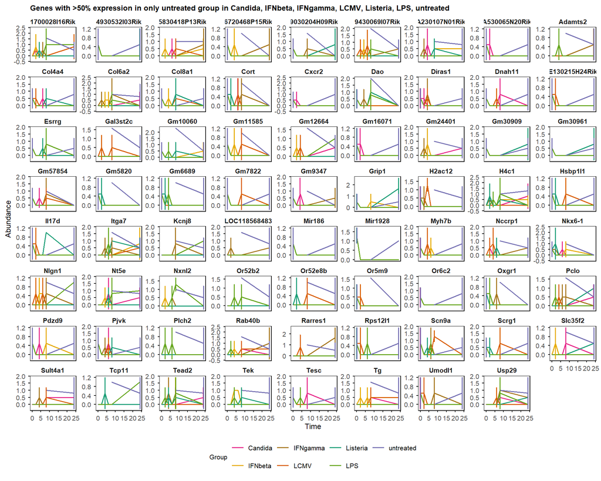

```r
plot_trend(table_mean_sd_orig,
    features = group_unique_genes_list[["untreated"]],
    title = paste0("Genes with >", 100 * filter_ratio, "% expression in only untreated group"))
```

Features with enough values in only one group will be excluded from variance decomposition, because the group contributed variance is unknown.

# 10 Segmented regression analysis

## 10.1 Impute with group minimum (replicates merged by mean)

no NA values in this dataset so imputation will not change the data

```r
data_obj_merged_imp_list <- impute_groups(data_obj_merged_list)
```

```
#> Group Candida: no missing values.
#> Group IFNbeta: no missing values.
#> Group IFNgamma: no missing values.
#> Group LCMV: no missing values.
#> Group Listeria: no missing values.
#> Group LPS: no missing values.
#> Group untreated: no missing values.
```

```r
data_obj_merged_imp_list %>% lapply(function(x) ncol(x))
```

```
#> $Candida
#> [1] 6
#>
#> $IFNbeta
#> [1] 6
#>
#> $IFNgamma
#> [1] 6
#>
#> $LCMV
#> [1] 6
#>
#> $Listeria
#> [1] 6
#>
#> $LPS
#> [1] 6
#>
#> $untreated
#> [1] 3
```

## 10.2 Run Trendy

time consuming, load from presaved results.

`run_Trendy()` accepts optional `group` and `minExp` parameters for finer control over which groups to analyse and expression filtering.

```r
assays(data_obj_merged_imp_list$IFNbeta)[[1]] %>%
    rowMeans() %>%
    summary()

res_list <- run_Trendy(data_obj_merged_imp_list,
    maxK = 1,
    minNumInSeg = 2,
    meanCut = 0,
    NCores = 16
)
```

```r
# save(res_list, file = paste0("output\\TiDEomics_application_1_trendy_results_k1_", Sys.Date(), ".rda"))
load("output\\TiDEomics_application_1_trendy_results_k1_2026-04-24.rda")
```

When # segments = 2 (maxK = 1) and minNumInSeg = 2, at least 4 time points are needed.

Untreated group with only 3 time points were not analysed by `run_Trendy()`

## 10.3 Visualise results

Segments of example genes

```
#> Plotting segmented regression for group: Candida
```

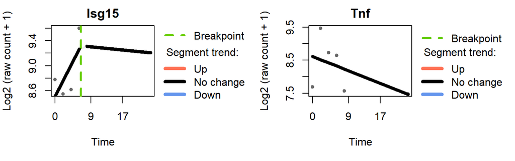

```
#> Plotting segmented regression for group: IFNbeta
```

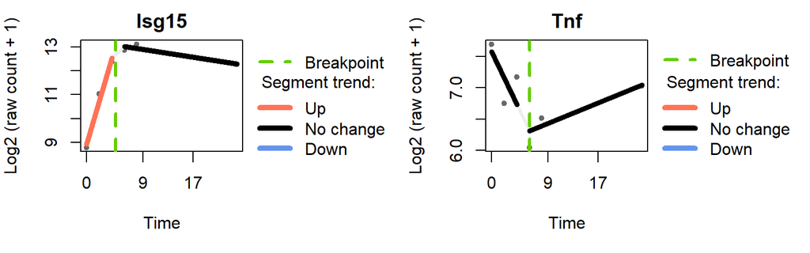

```
#> Plotting segmented regression for group: IFNgamma
```

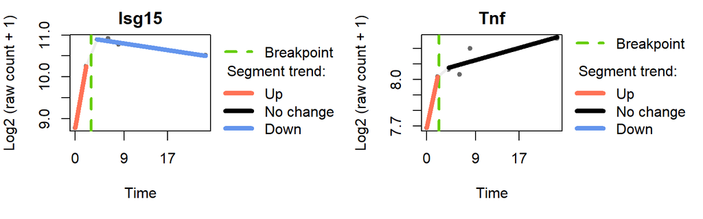

```
#> Plotting segmented regression for group: LCMV
```

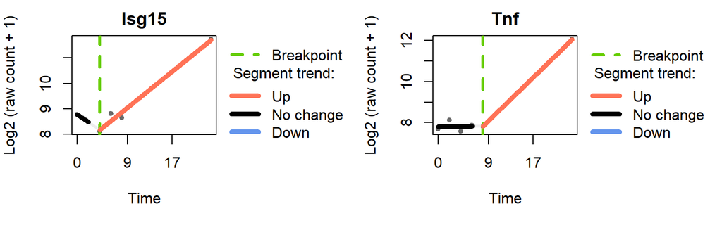

```
#> Plotting segmented regression for group: Listeria
```

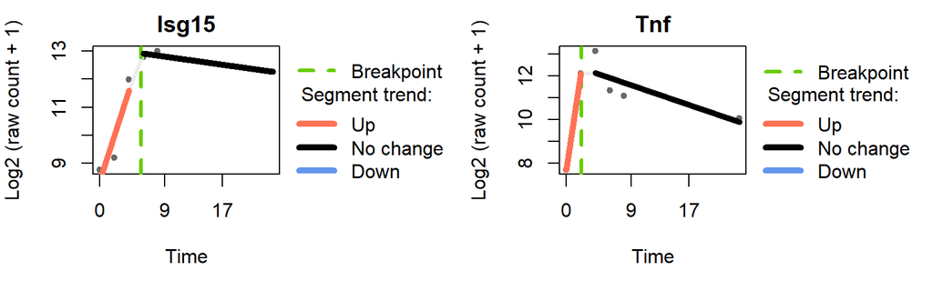

```
#> Plotting segmented regression for group: LPS
```

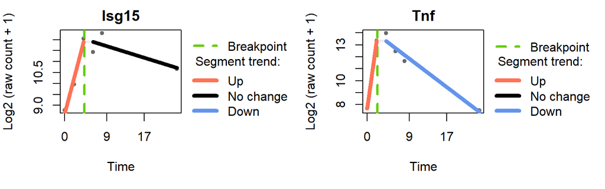

```r
plot_segments(data_obj_merged_imp_list,
    res_list,
    feature = c("Isg15", "Tnf"), # example features
    ylab = "Log2 (raw count + 1)"
)
```

Breakpoint distribution and details per group

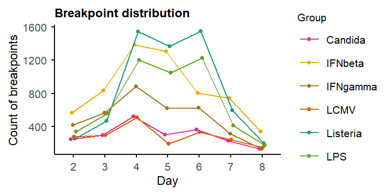

```r
plot_breakpoints(res_list)
```

```r
trendy_summary <- summarise_Trendy(res_list)
trendy_summary %>% head()
```

|  | Group | Feature | Segment1.Slope | Segment2.Slope | Segment1.Trend | Segment2.Trend | Segment1.Pvalue | Segment2.Pvalue | Breakpoint | AdjustedR2 | X0.Trend | X2.Trend | X4.Trend | X6.Trend | X8.Trend | X24.Trend | Pattern |
| --- | --- | --- | --- | --- | --- | --- | --- | --- | --- | --- | --- | --- | --- | --- | --- | --- | --- |
| Candida.Rpl7-ps8 | Candida | Rpl7-ps8 | -0.396240 | -8.6042e-15 | down | stable | 2.379709e-13 | 0.399867490 | 3.261860 | 1.0000000 | -1 | -1 | 0 | 0 | 0 | 0 | down_stable |
| Candida.St7 | Candida | St7 | 0.488900 | -1.6671e-02 | up | down | 2.264707e-03 | 0.005927977 | 2.900048 | 0.9999139 | 1 | 1 | -1 | -1 | -1 | -1 | up_down |
| Candida.Afp | Candida | Afp | 0.229110 | -3.0930e-02 | up | down | 3.015636e-03 | 0.008827659 | 6.761040 | 0.9997082 | 1 | 1 | 1 | 1 | -1 | -1 | up_down |
| Candida.Itga1 | Candida | Itga1 | -0.075321 | -1.1330e-02 | down | down | 5.370359e-03 | 0.014103997 | 6.788491 | 0.9995142 | -1 | -1 | -1 | -1 | -1 | -1 | down_down |
| Candida.Psip1 | Candida | Psip1 | -0.179080 | 2.4543e-02 | down | up | 5.597852e-03 | 0.008279258 | 4.878955 | 0.9992539 | -1 | -1 | -1 | 1 | 1 | 1 | down_up |
| Candida.Ttc38 | Candida | Ttc38 | -0.169900 | 4.7665e-02 | down | up | 7.024327e-03 | 0.005075959 | 4.336652 | 0.9991648 | -1 | -1 | -1 | 1 | 1 | 1 | down_up |

```r
trendy_list <- extract_segment_trends(trendy_summary)
# trendy_list$IFNbeta
```

Example genes with different segment patterns

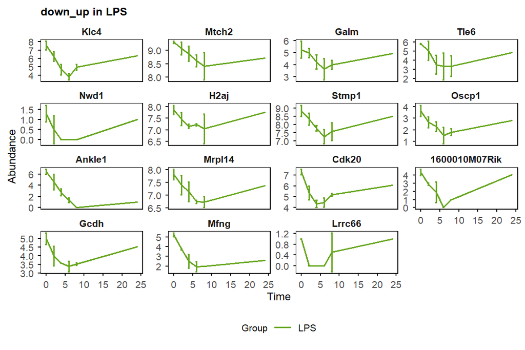

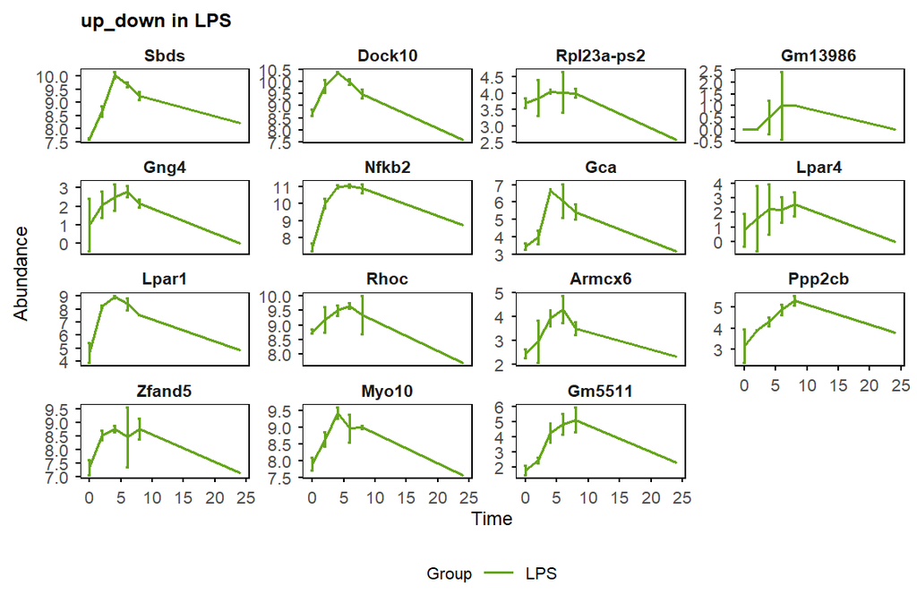

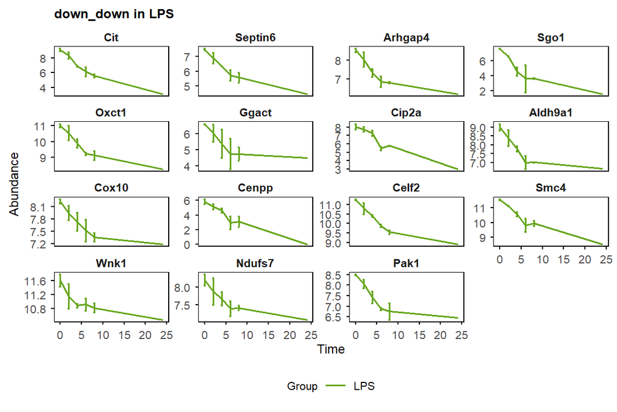

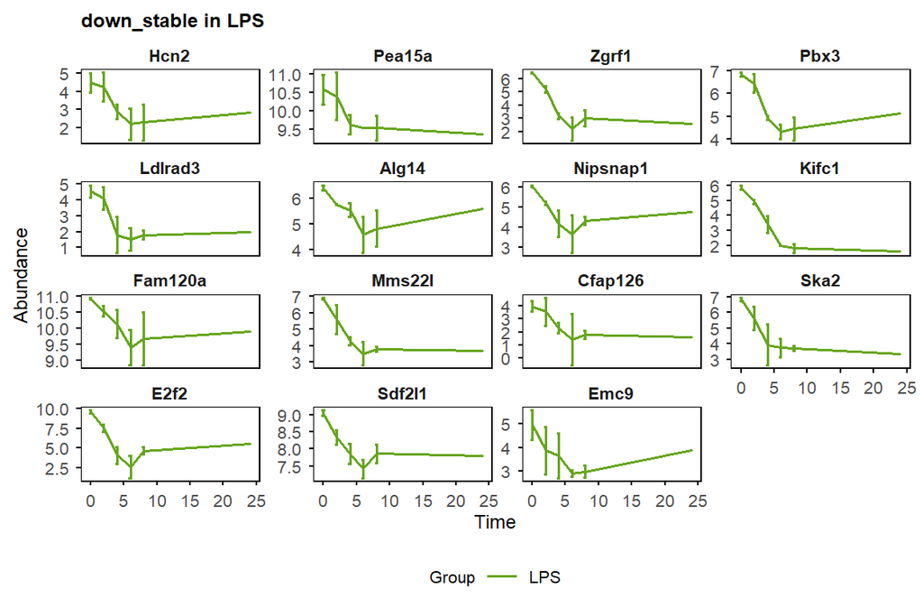

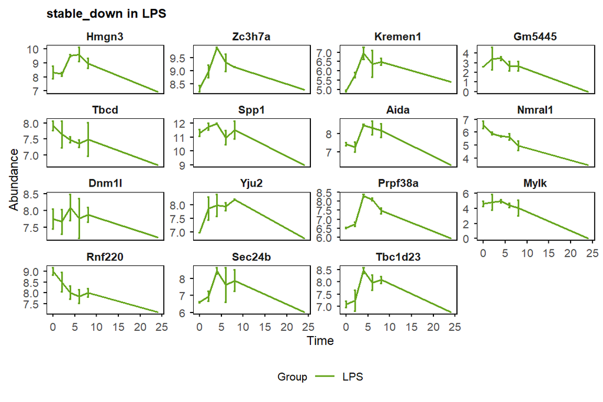

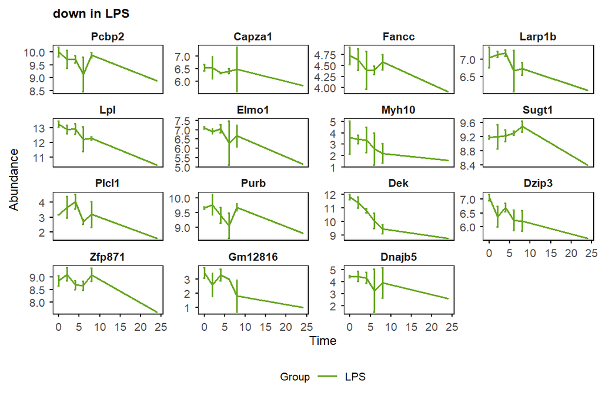

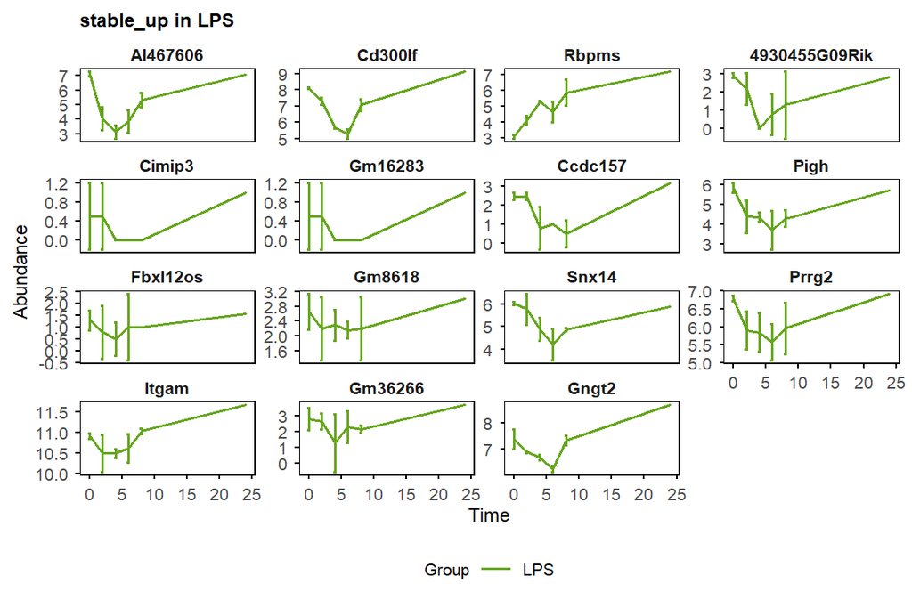

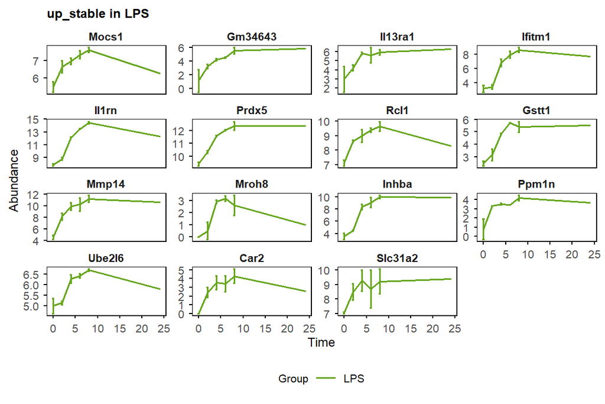

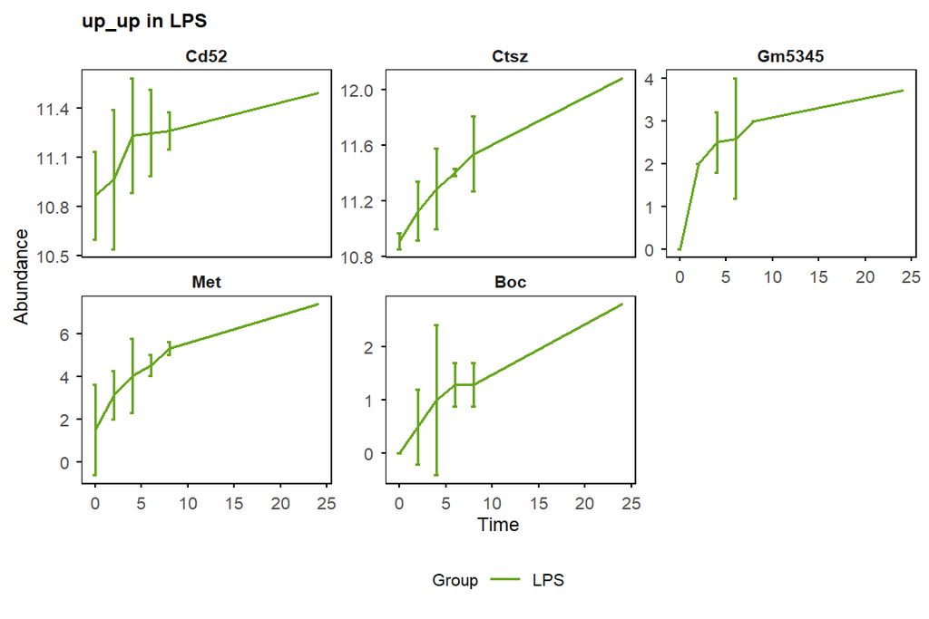

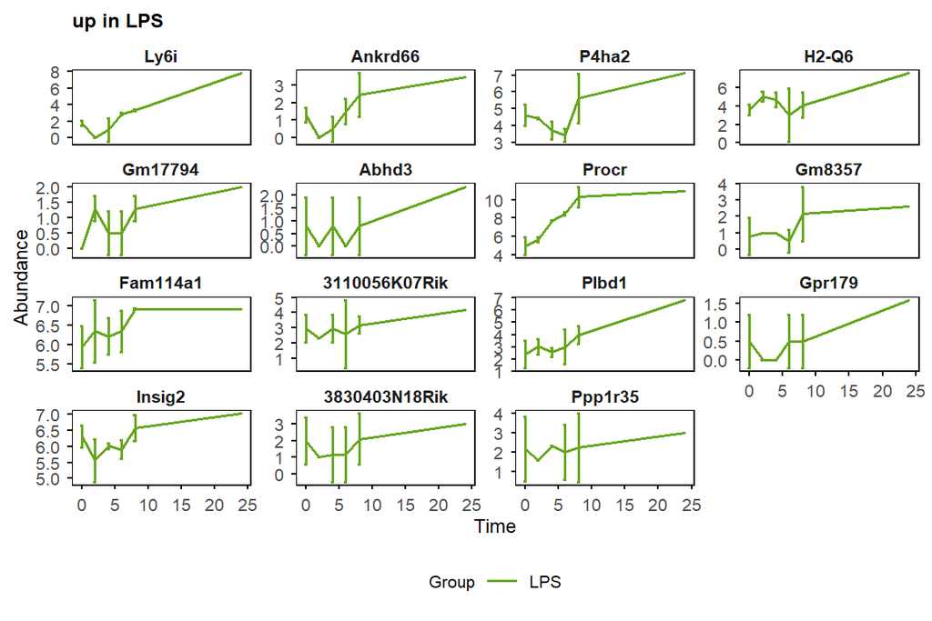

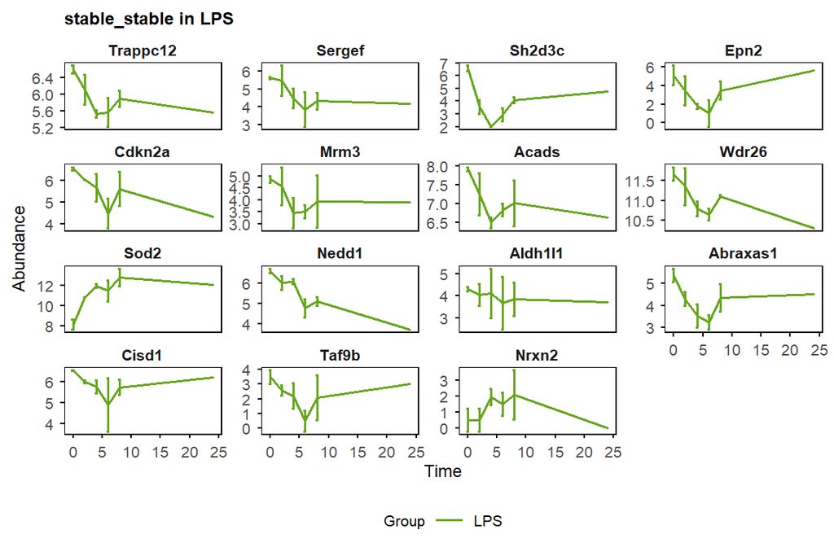

```r
# plot example genes with different trend patterns
i <- "LPS"
for (j in names(trendy_list[[i]])) {
    if (!is.null(trendy_list[[i]][[j]])) {
        plot_trend(table_mean_sd_orig,
            groups = i,
            features = trendy_list[[i]][[j]] %>%
                sample(min(15, length(trendy_list[[i]][[j]]))),
            title = paste0(j)
        )
    }
}
```